# Reporte Hito 1

### Integrantes: Sebastián Contreras, Eric Kirchgessner, Josefa Muñoz, Nahuel Gómez y Felipe Escárate.

## Introducción

### Problema a tratar:

Análisis de pobreza en Chile considerando factores multidimensionales como las características del hogar (número de personas, locación, etc), el nivel educativo, etc.

### Motivación:

La encuesta CASEN (Caracterización Socioeconómica Nacional) recopila datos sobre la situación socioeconómica de Chile, incluyendo factores multidimensionales como educación, género, situación de salud, etc. Los resultados de esta encuesta están disponibles en su sitio oficial, desde el cual se pueden obtener como bases de datos.

Se puede analizar la pobreza en Chile considerando varios factores y con diferentes gráficos, considerando también el nivel de educación en Chile, se pueden llegar a conclusiones sobre la relación entre pobreza y educación, comparándolos con el análisis hecho por CASEN.

En particular, el interés del grupo se centra más en datos actuales, por lo cual se eligieron las encuestas de los años 2013, 2015, 2017 y 2020. Agregado a esto, está la relevancia social que implica trabajar con datos de las familias de Chile.

## Exploración de datos

Las bases de datos de la encuesta CASEN cuentan con una gran cantidad de columnas, variando entre 600 y 800 atributos diferentes y sumando un total de 887.335 filas en total. Es importante mencionar que en el dataset original puede existir más de una respuesta por folio o residencia. Debido a esto se optó por un preprocesamiento en el cual se filtraron las columnas que se consideraron más relevantes para el análisis (folio, ytoth o ingresos totales, región, comuna, zona y año), dejando de lado columnas poco relevantes y columnas con muchos NaNs. También se agruparon las respuestas por folio y se estandarizaron los formatos de fecha para que se compartiera un estándar común entre las bases de datos de diferentes años.

Una primera exploración intuitiva es la de apreciar los datos estadísticos del dataset completo a través de la agregación en función del año de las respuestas y su visualización con boxplot para interpretar de mejor forma los datos.

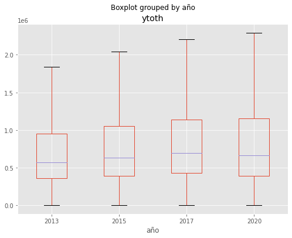

De este gráfico se puede ver claramente los diferentes cuartiles, las medianas y se puede apreciar que el 2013 es el año con menor ingreso total y además que los datos presentan una gran dispersión.

Otra exploración bastante intuitiva es ver la variación del ingreso total a través de los años agregando en función de la región. Para facilitar la visualización y no ocupar tanto espacio se agruparon los gráficos de las regiones por zona. A modo de ejemplo, se muestra el gráfico correspondiente a la zona centro (los demás se encuentran adjuntos en el código fuente).

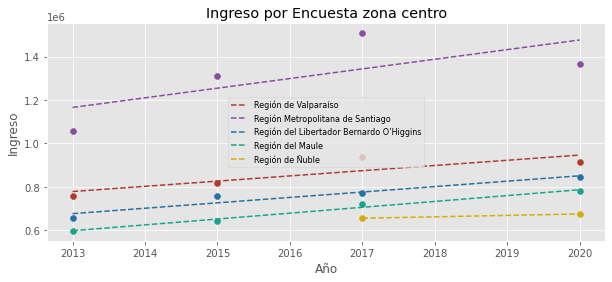

De estos gráficos se puede apreciar que la mayoría de las regiones tienden a incrementar sus ingresos totales a través del tiempo

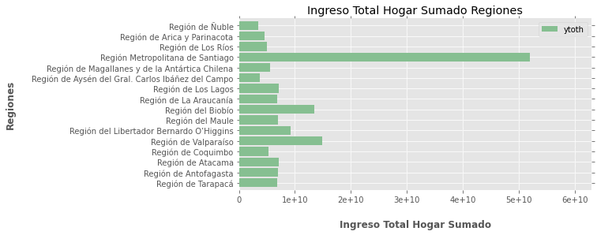

## Preguntas y Problemas

Existen preguntas que se pueden resolver sin usar minería de datos, dentro de estas encontramos

- ¿Cuántas regiones sumadas reciben el mismo ingreso que la RM?
- ¿Cómo varían los ingresos en cada encuesta?
- ¿Que region ha crecido/decrecido más según sus ingresos?

Con lo que el set de preguntas a responder en el Hito 2 está conformado por las siguientes:

- ¿Se puede predecir el nivel de pobreza según el nivel educativo?
- ¿Se podrían predecir la localización de un hogar en base a sus datos socioeconómicos?
- ¿Es posible hacer un clustering de los hogares, de tal forma que se encuentren categorías con características inesperadas?
- ¿Es posible hacer un clustering de los individuos, de tl forma que se encuentren categorías con características inesperadas?
- ¿Es posible ver alguna tendencia relacion entre las siguientes variables?
  - Cantidad de personas en el hogar y el nivel socioeconómico
  - Rol de hogar, edad, sexo y estudios

Se da cuenta que, las dos primeras preguntas entran en la categoría de aprendizaje supervisado, la tercera y cuarta pregunta se resolverían con clustering y la quinta va ligada a realizar un análisis, con lo cual, se usarían varias técnicas de Machine Learning, incluyendo las nombradas anteriormente.

# Reporte Hito 2

## Propuestas metodológica experimental inicial

### Pregunta 1

¿Se puede predecir el nivel de pobreza según el nivel educativo?

Se utilizarán los clasificadores KNN y árbol de decisión. Los parámetros para medirlo serán los vistos en los laboratorios F1-score, Recall y Acuracy y Precision.

Para realizar una correcta clasificación, se necesitarán dos variables y una clase a la que asignar los datos. Será necesario agregar la columna "e6b" (último nivel aprobado o que está cursando actualmente), la columna "e6a" (nivel educacional más alto alcanzado) y se agregará una columna correspondiente a la clase que indique el decil al que pertenece cada hogar en función de su ingreso total. La información entregada por la columna ‘e6b’ no es tan relevante como la de ‘e6a’ pero es la única que aporta información que tiene importancia real para poder determinar el nivel educativo. Antes de seguir, se deben limpiar los datos de la columna "e6b" que tengan valores blancos (99 o 0).

Con todo esto se pueden armar los arreglos del par de variables por tupla y el de su clasificación respectiva para poder intentar predecir el decil al que pertenece un hogar a partir de los atributos que definen su nivel educativo. Se segmenta el dataset, dejando un 70% para entrenar y un 30% para predecir y luego solo resta correr el entrenamiento, las predicciones y las métricas de precisión sobre el árbol de decisión y el KNN. Dependiendo de las métricas, se elegirá el mejor modelo para responder.

### Pregunta 2

¿Se podría predecir la localización de un hogar en base a sus datos socioeconómicos?

En primer lugar, se consideraría la comuna como la localización del hogar, es decir, la clase a utilizar. Como se tienen muchas clases, se puede probar dividir el proceso en dos etapas, cada una utilizando distintos clasificadores. En la primera etapa se predeciría la región del hogar mientras que en la segunda, se predeciría la comuna a partir de la región predicha anteriormente.

Para entrenar al/los modelo/s, se utilizarán los atributos ytoth, numper, tipo de vivienda , cantidad de dormitorios, de donde se obtiene el agua y tipo de sistema de eliminación de excretas (notar que la única que se encontraba en el set de columnas del hito 1 es "ytoth"). Estas columnas se eligen porque tienen pocos (o ningún) valor nulo. Además, se debe tomar en cuenta el atributo Factor de expansión regional, con la finalidad de darle la representatividad correspondiente a cada dato de una región determinada.

Cabe destacar, que si bien hay datos que tienen una alta correlación con la variable comuna, estos no son útiles para el modelo, ya que en general tienen relación directa con la comuna (ej: región, id_comuna) o tienen un alto porcentaje de valores nulos.

OBS: Notar que en la tabla del 2013 falta la categoría “vivienda tradicional indígena” y en la del 2020 se agrupan las casas y departamentos en sólo 2 categorías pero estas son especificados en los atributos v1_casa y v1_depto.

Una vez obtenidos los datos para las cuatro tablas se comenzaría a entrenar los clasificadores con estos datos (para esto, los datos se deben segmentar en 70% de entrenamiento y 30% de testing). Se probaría con Random Forest, Naive Bayes y KNN, en caso de un mal desempeño de este último, se probaría borrando algunas columnas para evitar la maldición de la dimensionalidad. Finalmente se evaluarían los modelos con las métricas conocidas (accuracy, precision, recall y f1-score).

### Pregunta 3

¿Es posible hacer un clustering de los hogares, de tal forma que se encuentren categorías con características inesperadas?

Primero se seleccionan todos los valores posibles que apliquen a un hogar entero: ingresos, niveles de educación, acceso a salud, región, rubro laboral de los jefes de hogar y (columnas exactas por verse).

Algunos datos tendrán que ser pre-procesados para que sea posible calcular la distancia: Una razón entre integrantes hombres del hogar e integrantes mujeres del hogar; una edad promedio de los integrantes del hogar; coordenadas promedio para la comuna/región en que se encuentra el hogar.

Con estos datos, se hará una matriz con los datos que resulten más interesantes (y que no sean dependientes entre sí). Luego, se realizarán distintos tipos de clustering, esperando tener un resultado que nos indique alguna información interesante.

- Clustering jerárquico: Se generan varios dendogramas de los datos para intentar identificar visualmente un número de clusters razonable (una altura de corte que distribuya equitativamente en categorías los datos).

Se aplica clustering aglomerativo, y se grafica el dataset clusterizado con reducción de dimensionalidad usando PCA.

- K-Means: Primero se aplica K-Means varias veces, graficando los resultados para poder usar el método del codo y encontrar un valor razonable para K (comparando con los resultados del clustering jerárquico).

Luego, se hace una optimización de los hiperparametros, cada vez graficando en 2D el dataset clusterizado con reducción de dimensionalidad usando PCA. Bisecting.

- K-Means: Se repite el proceso realizado para k-means.
- DBscan: Usando el método de la rodilla, se estima un buen valor para epsilon. Luego se crean clusters usando DBscan, mientras que min_sample será iterado en varios valores, hasta alcanzar el minimo silhouette.

Una vez calculados clusters óptimos con distintos métodos, se grafican con una librería como pyplot de manera que se puedan inspeccionar los puntos individuales de data en cada clúster. Aplicando reducción de dimensionalidad usando PCA, y potencialmente graficando en tres dimensiones. Esto es con propósito de ver si existe algún patrón que define cada cluster.

Algunos ejemplos de patrones interesantes que se podrían buscar son: hogares de bajo nivel educativo con altos ingresos; un cluster que justo corresponda con una cierta comuna o zona geográfica; un cluster de hogares con menos integrantes o más integrantes que otros clusters de ingresos similares; entre otros.

Para comparar todos los métodos de clustering distintos, y adicionalmente para verificar si tienen alguna coherencia los resultados, se aplican métodos de validación. Externos: Se calcula la pureza y la entropía. Internos: Se calcula el índice de Silhouette.

Con todo lo anterior, finalmente se responde la pregunta de si hubieron clustering esperadas o interesantes generadas al aplicar clustering a los datos. Si es que no hubieron conclusiones interesantes, se puede repetir todo el proceso con más datos en la parte inicial (Extendiendo a otros indicadores sociales como el acceso a salud, por ejemplo).

### Pregunta 4

¿Es posible hacer un clustering de los individuos, de tal forma que se encuentren categorías con características inesperadas?

Se seleccionaran los siguientes datos del dataset: Cuál fue el nivel educacional más alto alcanzado o el nivel educacional actual? (e6a), eliminando nulos y los pertenecientes a 99 NS/NR; nivel Educacional (educ); ocupación u oficio (oficio1); ¿Cuál es su ocupación u oficio? (4 dígitos) (oficio4); ¿Su trabajo o negocio principal es de tipo…? (o12); Categoria ocupacional (o15); Ingreso total (ytoth); Sexo; Edad; ¿A qué sistema previsional de salud pertenece usted? (s12); En una escala de 1 a 7, ¿Qué nota le pondría a su estado de salud actual? (s13); ¿Tiene alguna de las siguientes condiciones permanentes? (s31a1); ¿Cuál es la nacionalidad? (r1a); ¿Tiene acceso a conexión pagada: Tablet o dispositivo con plan de datos que permite conexión a internet? (r17d); Parentesco con jefe de núcleo (pco2); Region, provincia y comuna; Zona (rural o urbana); Situación de pobreza multidimensional con entorno y redes (5 dimensiones).

Con estos datos, primero se eliminarán los nulos y luego se realiza una matriz de correlaciones. La matriz de correlaciones nos indicará preliminarmente cuánto se relacionan ciertas variables, y cuáles relaciones nos conviene priorizar.

- K-means : Utilizando el método del codo, se elige un k conveniente para cada uno de los casos.
- Clustering jerárquico aglomerativo: Graficando dendogramas, elegiremos el y que más sentido haga para cada propósito.
- DBscan: A diferencia de la pregunta anterior, se elige de partida no utilizar este método debido a la alta dimensionalidad de los datos.

De todos los métodos anteriores, se seleccionará el que haya obtenido un mejor silhoutte_score.

Luego, se realizará un gráfico de barras de todas las variables para cada grupo del cluster, permitiendo obtener una caracterización. En base a esta caracterización, se espera detectar relaciones inesperadas en los grupos.

### Pregunta 5

¿Es posible ver alguna tendencia relacion entre las siguientes variables?

- Cantidad de personas en el hogar y el nivel socioeconómico
- Jefes de hogar, edad, sexo y estudios

Dado que en esta pregunta intentaremos hallar relaciones, se probarán distintos tipos de clasificación y clustering. Una vez obtenidos los distintos ejemplos, se optará por tomar las decisiones que tengan un mejor acierto según las mediciones vistas en clases.

**Cantidad de personas en el hogar y el nivel socioeconómico:**

Gracias al atributo “pco1” el cual indica el parentesco con el jefe de hogar, se sacan todas las respuestas correspondientes a la cantidad de integrantes del hogar. El nivel socioeconómico viene determinado por el atributo “ytoth” que indica los ingresos del hogar.

Dado el desconocimiento de los datos, se procederá con los tres tipos de clustering vistos, luego se verificarán resultados con el coeficiente de Silhouette

- K-means: Mediante el procedimiento del “codo” se elige un k conveniente. Se grafica con su respectiva matriz de similitud.
- Jerárquico: Se realiza un gráfico para cada una de las 4 formas de clustering jerárquico y se elige el corte conveniente en el eje y.
- DBScan: eps es estimado con el método de la rodilla, mientras que min_sample será iterado en varios valores, hasta alcanzar el minimo silhouette. Finalmente se grafica el que obtuvo mejores resultados.

Se comparan los clusterings según el coef antes mencionado, se elige el que contenga un número más cercano a 1. Se observa el mejor clustering y se toman conclusiones acerca de las relaciones.

Nota: En caso de que no se arrojen resultados concluyentes, se podría trabajar con los valores promedios de respuesta de los hogares.

**Rol en el hogar, edad, sexo y estudios**

Filtrar los datos dejando solo a los jefes del hogar mediante la columna "pco1". Se extraen las dos etiquetas de “pco1” con más repeticiones (podría extenderse a 3, habría que comparar resultados de entrenamiento).

Se realizará una matriz de correlaciones para ver lo que se espera del clasificador (hacernos una idea).

Al igual que en el lab 2.2, se utilizará VotingClassifier para obtener un resultado más preciso. Los clasificadores que se usarán serán KNN, Decision Tree y Bayes. Con estos, se espera obtener las métricas promedio de F1, Recall y precision, todo esto, con un entrenamiento del 70% de los datos.

Nota 1: En caso de que los parámetros presenten un desbalance notorio (un dato sea aproximadamente el doble del otro), se preprocesarán los datos para trabajar con (sub/over) sampling, esto esperando obtener una mejor predicción para los datos.

Nota 2: En caso de no llegar a resultados concluyentes, se mezclarán categorías similares, por ejemplo, se pueden juntar todas las categorías que hacen mención a la pareja, independiente del sexo de esta.

[BONUS] Se agregaron otras preguntas que no se resuelven con minería de datos, pero que resultan interesantes para los integrantes del grupo:

- Gráficos que indiquen cómo ha aumentado la cantidad de mujeres jefas de hogar
- ¿Existen comunas de la RM que tengan más ingresps que algunas regiones? (se consideran ingresos de la comuna/region como la suma de los ingresos del hogar)

# Reporte Hito 3

## Realización de lo planteado anteriormente

Una vez teniendo la metodología para resolver las preguntas planteadas, se pasó a aplicarla tal como se explicó anteriormente. Sin embargo, en algunos casos fue necesario cambiar el curso de acción debido a un funcionamiento inesperado de la metodología, ya sea por resultados peores a lo esperado o por problemas con la capacidad del hardware utilizado para computar los algoritmos.

### Pregunta 1

El objetivo planteado para resolver esta pregunta es el de predecir el nivel de pobreza en base al nivel educativo. Esta pregunta se respondió en el Hito 2, de lo cual, el mejor resultado alcanzado fue obtenido a partir de un Árbol de decisión, que logró alrededor de un 65% en algunas métricas vistas a lo largo del curso (Presición, Recall, F1-Score).

Ahora, ¿Se puede predecir el nivel de pobreza según el nivel educativo?. Si bien, los resultados obtenidos son mejores que el azar, la respuesta es no se nos hace posible actualmente, dado que el porcentaje de incertidumbre sigue siendo más alto de lo esperado. Un modelo 'Dummy' entregaría un 50% (por ser clasificación binaria), lo cual, es menor a lo que se obtuvo con el Árbol de decisión, sin embargo, es un resultado relativamente cercano.

### Pregunta 2

En el Hito 2 se especificó que la respuesta a esta pregunta estaba ligada a algoritmos de clasificación, con lo cual se siguió la metodología mencionada, salvo algunos cambios que se llevaron a cabo debido a algunos resultados obtenidos y a ciertos problemas con el hardware utilizado.

Como se dijo en el hito anterior, en un principio se consideró la comuna como la localización del hogar, es decir, la clase a utilizar y como paso preeliminar se debía predecir la región. Entonces, en la primera etapa se predijo la región del hogar utilizando los clasificadores Naive Bayes, KNN y Random Forest.

Para entrenar los modelos que predecían las regiones, se utilizaron los atributos nombrados en el hito anterior y se agregaron los siguientes: `Factor de expansión comunal` (indica la representatividad de la encuesta a nivel comunal); `Material de construcción de los muros` e `Ingreso por habitante del hogar`.

Nota: Dado que la encuesta CASEN del año 2020, no tiene el atributo de "Material de construcción de los muros", no se utilizó ese dataset.

Luego, se segmentaron los datos en 66.6% entrenamiento y 33.3% testing y se corrieron los algoritmos. Se descartó el uso de KNN inmediatamente debido a los resultados obtenidos (alrededor de un 13% en las métricas vistas en el curso), y por el hecho de que no servía eliminar atributos para reducir dimensionalidad, esto porque cada característica por si sola no era suficiente para predecir la localización el hogar.

Además, se decidió hacer un oversampling a los datos según la representatividad de estos a nivel regional. Para esto se decidió replicar las filas del dataset según su factor de expansión regional, sin embargo, se tuvo un problema en la capacidad de computo del hardware por lo que solo se pudo replicar por $\frac{1}{5}$ de esa cantidad.

Una vez hecho el oversampling se corrieron los dos modelos que quedaban, obtieniendo mejores resultados con Naive Bayes (alrededor de un 80% en las métricas vistas a lo largo del curso, i.e: accuracy, precision, recall y f1-score). Con esto se podía pasar a la etapa de predecir la comuna, para lo cual se decidió utilizar Naive Bayes debido a su desempeño en la primera etapa.

Para predecir la comuna, simplemente se agregó el atributo de la `"región"`, sin embargo, al entrenar el modelo, el computador utilizado se quedó sin memoria RAM, por lo cual, se intentó sortear este problema de distintas maneras, como por ejemplo:

- Utilizar otro computador.
- Guardar el modelo y los datos para poder correr la segunda parte con menos RAM ocupada.
- Utilizar menos datos para entrenar la segunda parte.

Sin embargo, el modelo seguía sin correr o cuando lo hacía entregaba resultados con métricas inferiores a las esperadas. Por todo esto, se podría decir que si tomamos la comuna como la ubicación del hogar no es posible predecirla, sin embargo, si sólo nos remitimos a tomar la localización de la región como la del hogar, sí podríamos decir que es posible predecirla a partir de los datos utilizados.

### Pregunta 3

La primera decisión fue trabajar inicialmente solo con los datos de 2017 para reducir el tiempo de procesamiento, y asegurar que todos los valores que se busquen estén presentes. La idea sigue siendo que si surgen conclusiones interesantes de este año, se puede profundizar agregando los restantes.

*Selección de columnas*

- Datos hogar : `folio`, `numper`, `region`
- Datos ingresos : `ytoth`, `o10`
- Niveles de educación : `educ`, `s12`, `s13`

#### Agregación y preprocesamiento

Como estamos estudiando a nivel hogar, se agrupa por hogar (`folio`), los ingresos y horas trabajadas (`ytoth`, y `o10`) se suman, el nivel educacional (`educ`) se considera el máximo en el hogar, el sistema de salud (`s12`) se considera el mínimo y el nivel subjetivo de bienestar salubre (`s13`) se considera la media de todo el hogar.

- Se quitan NaNs, valores sin respuesta y valores faltantes.
- Las regiones se ordenan discretamente de norte a sur, para que el calculo de distancia tenga sentido.

A primera vista, varios valores tienen suficiente nivel de correlación como para potencialmente generar resultados interesantes.

#### Clustering jerárquico

Para generar dendrogramas en un tiempo razonable, se tuvo que reducir en un décimo el set de datos, haciendo un sampling al azar. De los dendogramas generados, se determinó que los más prometedores son `complete` y `ward`.

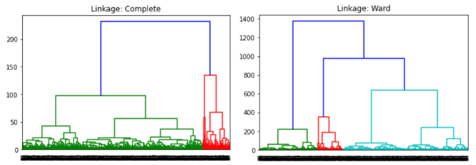

Reduciendo la dimensionalidad principal component analysis. Se pueden graficar los resultados del clustering.

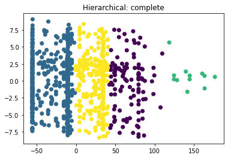

Aparte de los artefactos por el sampling al azar, parece haber ordenado en estratos simples los hogares, los linkages producieron resultados similares.

#### KMeans

Usando el método del codo, se determinó que el numero más razonable de clusters es 4.

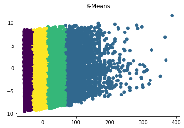

#### DBScan

Usando el método de la rodilla, se determinó un `eps` ideal; de 2.5.

Los resultados generados no son muy coherentes visualmente. Esto no es una sorpresa, ya que DBScan no suele funcionar bien para datasets de alta dimensionalidad, por lo que no se intentó profundizar mucho más este método.

#### Resultados

```
Silhouette Score K-Means k=4     0.6492660437876161
Silhouette Score Clustering Aglomerativo Complete    0.5224103335798964
Silhouette Score Clustering Aglomerativo Ward    0.6109984205524431
Silhouette Score DBSCAN  -0.6385068685101228
```

Viendo los gráficos, y el silhouette score, es claro que el mejor modelo es el K-Means con k=4. De todas formas se debe notar que no es un clustering ideal.

No se pudo hacer interactivo, entonces luego se hizo un análisis de las estadísticas de resumen de cada cluster resultante para poder ver si los resultados tienen alguna utilidad relevante a la pregunta.

### Análisis de los clusters

|  | Número hogares | Ingresos (suma) | Región | Integrantes Hogar | Horas Trabajadas (suma) | Nivel Educativo (máximo) | Sistema de salud | Nivel de salud (promedio) |
| --- | --- | --- | --- | --- | --- | --- | --- | --- |
| Cluster 1 | 18427 hogares | El grupo de menores ingresos, su promedio siendo la mitad del grupo que sigue. | En promedio, centralizado. | Suelen tener la menor cantidad de integrantes en el hogar. En particular, esto indicaría que son individuos que viven solos o en pareja | Gran parte de este grupo parece ser cesante. | Bajo. | Tendencia a salud publica. | Mediano. |
| Cluster 2 | 28428 hogares | El grupo de segundos menores ingresos, su promedio siendo el doble del grupo menor y la mitad del grupo que lo sigue. | En promedio, centralizado. | Tienen una cantidad promedio de integrantes por hogar. | El número de horas trabajadas en este grupo indica que solo un integrante del hogar suele percibir ingresos. | Mediano. | Tendencia a salud publica. | Alto. |
| Cluster 3 | 18046 hogares | El grupo de terceros menores ingresos, su promedio siendo el doble que el grupo anterior. | Tiende levemente hacia el norte. | Tienen una cantidad promedio de integrantes por hogar. | El número de horas trabajadas en este grupo indica que dos integrantes del hogar suelen pericbir ingresos. | Alto. | La mayor tendencia a salud privada. | Similar al grupo 4. |
| Cluster 4 | 5125 hogares | El grupo de mayores ingresos. | Tiende fuertemente más hacia el norte. | Suelen tener la mayor cantidad de integrantes en el hogar. En particular, esto indicaría que son hogares generacionales establecidos. | El grupo que mas horas acumuladas trabaja, lo que indica que varios integrantes del hogar trabajan. | Alto. | Tendencia a salud privada. | Similar al grupo 3. |

Básicamente, fue una forma más detallada/holística de dividir los hogares en estratos sociales. Para responder la pregunta, por lo menos con las metodologías probadas no surgieron resultados particularmente sorprendentes, pero si tiene cierto mérito en una forma innovadora de considerar estratos sociales de los hogares, y que aspectos socioeconómicos varían entre estas.

### Pregunta 4

Utilizando las columnas ['sexo', 'edad' , 'ytoth', 'region', 'comuna', 'zona', 'año', 'e6a', 'educ', 'o15', 'pco2', 'folio'], se reemplazó la columna ytoth por decil calculado en base a esta, además, se tuvo que eliminar ['r17d','s31a1', 'oficio1', 'oficio4', 'o12', 's12', 'r1a', 's13'] debido a que su uso era incosistente en distintos años.

Para los K-Means se ocupó todo el dataset, mientras que para el Aglomerativo solo se utilizó el 10% debido a limitaciones de memoria RAM de Google Colab.

#### Resultados de silhouette score:

- K-Means [2 clusters]: 0.7630543352895385
- K-Means [3 clusters]: 0.7941053052910256
- K-Means [4 clusters]: 0.7852606454828674
- Clustering jerárquico aglomerativo 3 clusters: 0.7842660983241164

Por lo que el mejor modelo fue el de K-Means con 3 clusters.

#### Resultado en común de lso grupos

- Las edades de los individuos se reparten siguiendo una distribución normal.
- En la pregunta: "En su trabajo o negocio principal, ¿usted trabaja cómo?" las respuestas eran mayoritariamente: "Empleado del sector privado" y "Trabajador por cuenta propia" [(o15): respuestas 5 y 2].
- Generalmente respondían los jefes de núcleo [pco2 igual a 1]

*Grupo 1:*

`Decil` : Tendencia a primeros deciles.\ `Regiones`: Todas, mayoritariamente 13, 8 y 5.\ `Nivel educacional más alto alcanzado(e6a)`: 9,7,6,8 : Media, Básica, Primaria, `Humanidades`.\ `Nivel de escolaridad(educ)`: 5,1,2,3,11: Media Humanista completa, Básica incompleta, Básica Completa, Media humanista incompleta, Postgrado incompleto.

*Grupo 2:*

`Decil` :Tendencia a últimos deciles.\ `Regiones`: de 10 a 16, mayoritariamente 13.\ `Nivel educacional más alto alcanzado(e6a)`: 9,7,15 : Media, Básica, Profesional Completo muy similares en cantidad.\ `Nivel de escolaridad(educ)`: 5,1,2,3,11: Media Humanista completa, Básica incompleta, Básica Completa, Media humanista incompleta, Postgrado incompleto.

*Grupo 3:*

`Decil` : Tendencia a primeros deciles.\ `Regiones`: 4 a 9 y 16, mayoritariamente 8 y 5.\ `Nivel educacional más alto alcanzado(e6a)`: 9,7,15 : Media, Básica, Profesional Completo.\ `Nivel de escolaridad(educ)`: 5,1,2,3,8, 6: Media Humanista completa, Básica incompleta, Básica Completa, Media, humanista incompleta, Técnico nivel superior completo, Media técnica profesional completa.

### Pregunta 5

- Cantidad de personas en el hogar y el nivel socioeconómico

Primero se extrajeron las columnas de interés y se filtró para seleccionar solo a los jefes de hogar (pco1 = 1). Procediendo por el 'método del codo', se elige un número de clusters para cada una de las encuetas casen y para un dataframe que contiene todos los datos juntos. En promedio, el número de cluster fue 4, sin embargo, el plot de los gráficos no fue el esperado:

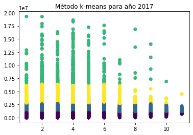

Por lo que se probaron valores en una representación 3D, pasando por datos relacionados a Educacion ('e6a') e ingresos por persona (valor que se agregó solo para buscar variaciones en el plot), en ninguno se obtuvo un resultado esclarecedor:

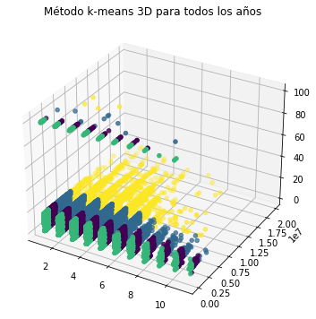

En este punto ya se intuía que no se podría esperar encontrar una relación con los datos. Esta intucición nace dado que la variable 'numper' es 'demasiado discreta' y repetitiva, lo que hace la ilusión de que se estuviera realizando un gráfico de barras. De todas formas, se procedió por graficar la relación en algunas comunas de Santiago:

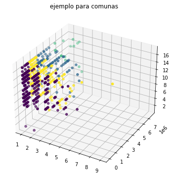

El dendograma de tipo completo, no arrojó resultados distintos, en la figura, ejemplo para calcular el numero de clusters:

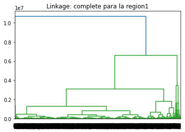

Y finalmente, el DBSCan no fue probado, esto dado que la densidad de los valores habría arorjado un grafico de barras aún más demarcado. Se concluye que no existe un clustering apto para las variables cantidad de personas y nivel socioeconómico.

- Rol en el hogar, edad, sexo y estudios

Tomando los datos del año 2020 como test, se procedió por elegir los valores de pco1 más comunes, filtrando por los parámetros 1 y 2. Se realizó una matriz de correlaciones para las variables 'edad', 'sexo', y 'e6a'. Se crearon funciones auxiliares y se utilizó el modelo del VotingClassifier visto en los labs para intentar predecir la educación de las personas.

Esperando aumentar el acierto, se procesaron los datos, pero en vez de usar oversampling, se agruparon los niveles educacionales, por ejemplo, los valores 'nunca asistió', 'kinder', 'pre kinder', 'jardin infantil' quedaron como una única variables, análogamente quedaro agrupados los demás niveles educacionales. Se extrajeron los 3 valores más repetivos de pco1, que sería dueño de casa, esposo/a e hijos. Finalmente se intentó predecir el nivel educacional de los integrantes, obteniendo los siguientes resultados:

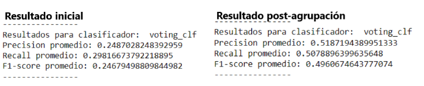

### Bonus

El bonus corresponden a preguntas de interés del grupo en las cuales, no es necesario utilizar minería de datos para sus respuestas. Las dejamos en caso de que el cuerpo docente comparta los mismos intereses.

- Gráficos que indiquen cómo ha aumentado la cantidad de mujeres jefas de hogar:

R: No fueron necesarios gráficos dado que los resultados eran bastante claros, se decidió por averiguar cuanto había variado el porcentaje de mujeres jefas de hogar. Se obtuvo un 37% para 2013, 38% para 2015, 41% para 2017 y un sorprendente 24% para 2020. Creemos quee ste último valor puede derivar de las irregularidades de la pandemia, se concluye que el porcentaje de mujeres jefas de hogar disminuyó con la pandemia.

- ¿Existen comunas de la RM que tengan más ingresps que algunas regiones? (se consideran ingresos de la comuna/region como la suma de los ingresos del hogar)

R: Antes de abordar la pregunta, se aclara la imprecisión, dado que el ingreso no corresponde al comuna/regional, sino que al hogar. Es decir, estamos buscando si en suma, existe alguna comuna de la RM que tenga mayores ingresos que una comuna.

Se concluye según la pregunta que existen regiones con menos ingresos promedios que las comunas, en particular se destaca la región 16, la cual recibe menos ingresos que 7 comunas de la RM —Santiago, Las Condes, Maipú, Ñuñoa, Providencia, Vitacura y Puente Alto—

## Aportes de cada integrante

- Creación del PPT : Josefa
- Grabación del video : Nahuel y Felipe (para sus preguntas), Eric, josefa y Sebastían para sus preguntas y el resto del video
- Desarrollo de los problemas : Cada uno desarrolló un problema. Problema Bonus, Nahuel
- Creación del informe : Nahuel y Felipe
- Edición del video : Eric

# Codigo Fuente

```python
import pandas as pd
import matplotlib.pyplot as plt
from sklearn import preprocessing
import numpy as np
```

```python
from google.colab import drive
drive.mount('/content/drive')
# se descargaron de http://observatorio.ministeriodesarrollosocial.gob.cl/encuesta-casen-en-pandemia-2020 y http://observatorio.ministeriodesarrollosocial.gob.cl/encuesta-casen
# viene en zip, hay que extraer
```

```python
df2013 = pd.read_stata('/content/drive/MyDrive/Matos/BBDD/casen_2013_mn_b_principal.dta', convert_categoricals=False)
df2015 = pd.read_stata('/content/drive/MyDrive/Matos/BBDD/casen_2015.dta',convert_categoricals=False)
df2017 = pd.read_stata('/content/drive/MyDrive/Matos/BBDD/casen_2017.dta', convert_categoricals=False)
df2020 = pd.read_stata('/content/drive/MyDrive/Matos/BBDD/casen_2020.dta',convert_categoricals=False)
```

## Preprocesamiento

```python
df2013.name = "Casen 2013"
df2015.name = "Casen 2015"
df2017.name = "Casen 2017"
df2020.name = "Casen 2020"

data_frames = [df2013, df2015, df2017, df2020]
```

### Diccionarios

```python
diccionarioRegiones = { 1 : "Región de Tarapacá",
                        2 : "Región de Antofagasta",
                        3 : "Región de Atacama",
                        4 : "Región de Coquimbo",
                        5 : "Región de Valparaíso",
                        6 : "Región del Libertador Bernardo O’Higgins",
                        7 : "Región del Maule",
                        8 : "Región del Biobío",
                        9 : "Región de La Araucanía",
                        10: "Región de Los Lagos",
                        11: "Región de Aysén del Gral. Carlos Ibáñez del Campo",
                        12: "Región de Magallanes y de la Antártica Chilena",
                        13: "Región Metropolitana de Santiago",
                        14: "Región de Los Ríos",
                        15: "Región de Arica y Parinacota",
                        16: "Región de Ñuble"}

diccionarioComunas =  { 1101 : "Iquique",
                        1107 : "Alto Hospicio",
                        1401 : "Pozo Almonte",
                        1402 : "Camiña",
                        1404 : "Huara",
                        1405 : "Pica",
                        2101 : "Antofagasta",
                        2102 : "Mejillones",
                        2103 : "Sierra Gorda",
                        2104 : "Taltal",
                        2201 : "Calama",
                        2203 : "San Pedro de Atacama",
                        2301 : "Tocopilla",
                        2302 : "María Elena",
                        3101 : "Copiapó",
                        3102 : "Caldera",
                        3103 : "Tierra Amarilla",
                        3201 : "Chañaral",
                        3202 : "Diego de Almagro",
                        3301 : "Vallenar",
                        3302 : "Alto del Carmen",
                        3303 : "Freirina",
                        3304 : "Huasco",
                        4101 : "La Serena",
                        4102 : "Coquimbo",
                        4103 : "Andacollo",
                        4104 : "La Higuera",
                        4105 : "Paiguano",
                        4106 : "Vicuña",
                        4201 : "Illapel",
                        4202 : "Canela",
                        4203 : "Los Vilos",
                        4204 : "Salamanca",
                        4301 : "Ovalle",
                        4302 : "Combarbalá",
                        4303 : "Monte Patria",
                        4304 : "Punitaqui",
                        4305 : "Río Hurtado",
                        5101 : "Valparaíso",
                        5102 : "Casablanca",
                        5103 : "Concón",
                        5105 : "Puchuncaví",
                        5107 : "Quintero",
                        5109 : "Viña del Mar",
                        5301 : "Los Andes",
                        5302 : "Calle Larga",
                        5303 : "Rinconada",
                        5304 : "San Esteban",
                        5401 : "La Ligua",
                        5402 : "Cabildo",
                        5403 : "Papudo",
                        5404 : "Petorca",
                        5405 : "Zapallar",
                        5501 : "Quillota",
                        5502 : "Calera",
                        5503 : "Hijuelas",
                        5504 : "La Cruz",
                        5506 : "Nogales",
                        5601 : "San Antonio",
                        5602 : "Algarrobo",
                        5603 : "Cartagena",
                        5604 : "El Quisco",
                        5605 : "El Tabo",
                        5606 : "Santo Domingo",
                        5701 : "San Felipe",
                        5702 : "Catemu",
                        5703 : "Llaillay",
                        5704 : "Panquehue",
                        5705 : "Putaendo",
                        5706 : "Santa María",
                        5801 : "Quilpué",
                        5802 : "Limache",
                        5803 : "Olmué",
                        5804 : "Villa Alemana",
                        6101 : "Rancagua",
                        6102 : "Codegua",
                        6103 : "Coinco",
                        6104 : "Coltauco",
                        6105 : "Doñihue",
                        6106 : "Graneros",
                        6107 : "Las Cabras",
                        6108 : "Machalí",
                        6109 : "Malloa",
                        6110 : "Mostazal",
                        6111 : "Olivar",
                        6112 : "Peumo",
                        6113 : "Pichidegua",
                        6114 : "Quinta de Tilcoco",
                        6115 : "Rengo",
                        6116 : "Requínoa",
                        6117 : "San Vicente",
                        6201 : "Pichilemu",
                        6202 : "La Estrella",
                        6203 : "Litueche",
                        6204 : "Marchihue",
                        6205 : "Navidad",
                        6206 : "Paredones",
                        6301 : "San Fernando",
                        6302 : "Chépica",
                        6303 : "Chimbarongo",
                        6304 : "Lolol",
                        6305 : "Nancagua",
                        6306 : "Palmilla",
                        6307 : "Peralillo",
                        6308 : "Placilla",
                        6309 : "Pumanque",
                        6310 : "Santa Cruz",
                        7101 : "Talca",
                        7102 : "Constitución",
                        7103 : "Curepto",
                        7104 : "Empedrado",
                        7105 : "Maule",
                        7106 : "Pelarco",
                        7107 : "Pencahue",
                        7108 : "Río Claro",
                        7109 : "San Clemente",
                        7110 : "San Rafael",
                        7201 : "Cauquenes",
                        7202 : "Chanco",
                        7203 : "Pelluhue",
                        7301 : "Curicó",
                        7302 : "Hualañé",
                        7303 : "Licantén",
                        7304 : "Molina",
                        7305 : "Rauco",
                        7306 : "Romeral",
                        7307 : "Sagrada Familia",
                        7308 : "Teno",
                        7309 : "Vichuquén",
                        7401 : "Linares",
                        7402 : "Colbún",
                        7403 : "Longaví",
                        7404 : "Parral",
                        7405 : "Retiro",
                        7406 : "San Javier",
                        7407 : "Villa Alegre",
                        7408 : "Yerbas Buenas",
                        8101 : "Concepción",
                        8102 : "Coronel",
                        8103 : "Chiguayante",
                        8104 : "Florida",
                        8105 : "Hualqui",
                        8106 : "Lota",
                        8107 : "Penco",
                        8108 : "San Pedro de la Paz",
                        8109 : "Santa Juana",
                        8110 : "Talcahuano",
                        8111 : "Tomé",
                        8112 : "Hualpén",
                        8201 : "Lebu",
                        8202 : "Arauco",
                        8203 : "Cañete",
                        8204 : "Contulmo",
                        8205 : "Curanilahue",
                        8206 : "Los Álamos",
                        8207 : "Tirúa",
                        8301 : "Los Ángeles",
                        8302 : "Antuco",
                        8303 : "Cabrero",
                        8304 : "Laja",
                        8305 : "Mulchén",
                        8306 : "Nacimiento",
                        8307 : "Negrete",
                        8308 : "Quilaco",
                        8309 : "Quilleco",
                        8310 : "San Rosendo",
                        8311 : "Santa Bárbara",
                        8312 : "Tucapel",
                        8313 : "Yumbel",
                        8314 : "Alto Biobío",
                        9101 : "Temuco",
                        9102 : "Carahue",
                        9103 : "Cunco",
                        9104 : "Curarrehue",
                        9105 : "Freire",
                        9106 : "Galvarino",
                        9107 : "Gorbea",
                        9108 : "Lautaro",
                        9109 : "Loncoche",
                        9110 : "Melipeuco",
                        9111 : "Nueva Imperial",
                        9112 : "Padre Las Casas",
                        9113 : "Perquenco",
                        9114 : "Pitrufquén",
                        9115 : "Pucón",
                        9116 : "Saavedra",
                        9117 : "Teodoro Schmidt",
                        9118 : "Toltén",
                        9119 : "Vilcún",
                        9120 : "Villarrica",
                        9121 : "Cholcho",
                        9201 : "Angol",
                        9202 : "Collipulli",
                        9203 : "Curacautín",
                        9204 : "Ercilla",
                        9205 : "Lonquimay",
                        9206 : "Los Sauces",
                        9207 : "Lumaco",
                        9208 : "Purén",
                        9209 : "Renaico",
                        9210 : "Traiguén",
                        9211 : "Victoria",
                        10101 : "Puerto Montt",
                        10102 : "Calbuc",
                        10104 : "Fresia",
                        10105 : "Frutillar",
                        10106 : "Los Muermos",
                        10107 : "Llanquihue",
                        10108 : "Maullín",
                        10109 : "Puerto Varas",
                        10201 : "Castro",
                        10202 : "Ancud",
                        10203 : "Chonchi",
                        10204 : "Curaco de Vélez",
                        10205 : "Dalcahue",
                        10206 : "Puqueldón",
                        10207 : "Queilén",
                        10208 : "Quellón",
                        10209 : "Quemchi",
                        10210 : "Quinchao",
                        10301 : "Osorno",
                        10302 : "Puerto Octay",
                        10303 : "Purranque",
                        10304 : "Puyehue",
                        10305 : "Río Negro",
                        10306 : "San Juan de la Costa",
                        10307 : "San Pablo",
                        11101 : "Coyhaique",
                        11201 : "Aysén",
                        11202 : "Cisnes",
                        11301 : "Cochrane",
                        11401 : "Chile Chico",
                        11402 : "Río Ibáñez",
                        12101 : "Punta Arenas",
                        12301 : "Porvenir",
                        12401 : "Natales",
                        13101 : "Santiago",
                        13102 : "Cerrillos",
                        13103 : "Cerro Navia",
                        13104 : "Conchalí",
                        13105 : "El Bosque",
                        13106 : "Estación Central",
                        13107 : "Huechuraba",
                        13108 : "Independencia",
                        13109 : "La Cisterna",
                        13110 : "La Florida",
                        13111 : "La Granja",
                        13112 : "La Pintana",
                        13113 : "La Reina",
                        13114 : "Las Condes",
                        13115 : "Lo Barnechea",
                        13116 : "Lo Espejo",
                        13117 : "Lo Prado",
                        13118 : "Macul",
```

```python
                        13119 : "Maipú",
                        13120 : "Ñuñoa",
                        13121 : "Pedro Aguirre Cerda",
                        13122 : "Peñalolén",
                        13123 : "Providencia",
                        13124 : "Pudahuel",
                        13125 : "Quilicura",
                        13126 : "Quinta Normal",
                        13127 : "Recoleta",
                        13128 : "Renca",
                        13129 : "San Joaquín",
                        13130 : "San Miguel",
                        13131 : "San Ramón",
                        13132 : "Vitacura ",
                        13201 : "Puente Alto",
                        13202 : "Pirque",
                        13203 : "San José de Maipo",
                        13301 : "Colina",
                        13302 : "Lampa",
                        13303 : "Tiltil",
                        13401 : "San Bernardo",
                        13402 : "Buin",
                        13403 : "Calera de Tango",
                        13404 : "Paine",
                        13501 : "Melipilla",
                        13502 : "Alhué",
                        13503 : "Curacaví",
                        13504 : "María Pinto",
                        13505 : "San Pedro",
                        13601 : "Talagante",
                        13602 : "El Monte",
                        13603 : "Isla de Maipo",
                        13604 : "Padre Hurtado",
                        13605 : "Peñaflor",
                        14101 : "Valdivia",
                        14102 : "Corral",
                        14103 : "Lanco",
                        14104 : "Los Lagos",
                        14105 : "Máfil",
                        14106 : "Mariquina",
                        14107 : "Paillaco",
                        14108 : "Panguipulli",
                        14201 : "La Unión",
                        14202 : "Futrono",
                        14203 : "Lago Ranco",
                        14204 : "Río Bueno",
                        15101 : "Arica",
                        15102 : "Camarones",
                        15201 : "Putre",
                        16101 : "Chillán",
                        16102 : "Bulnes",
                        16103 : "Chillán Viejo",
                        16104 : "El Carmen",
                        16105 : "Pemuco",
                        16106 : "Pinto",
                        16107 : "Quillón",
                        16108 : "San Ignacio",
                        16109 : "Yungay",
                        16201 : "Quirihue",
                        16202 : "Cobquecura",
                        16203 : "Coelemu",
                        16204 : "Ninhue",
                        16205 : "Portezuelo",
                        16206 : "Ránquil",
                        16207 : "Treguaco",
                        16301 : "San Carlos",
                        16302 : "Coihueco",
                        16303 : "Ñiquén",
                        16304 : "San Fabián",
                        16305 : "San Nicolás"
}
diccionarioIdsComuna = {}
for key in diccionarioComunas:
    diccionarioIdsComuna.update({diccionarioComunas.get(key) : key})

print(len(diccionarioIdsComuna))
```

```
324
```

### Estandarización de fechas

```python
df2013['fecha'] = df2013['fecha'].apply(lambda x: pd.to_datetime(str(x), format='%Y%m%d'))

df2013['año'] = df2013['fecha'].dt.year
df2015['año'] = df2015['fecha_año']
df2017['año'] = df2017['fecha_año']
df2020['año'] = df2020['fecha_entrev'].dt.year

def chequear_años(data: pd.DataFrame) -> None:
  """ Imprime los años y el numero de respuestas del CASEN que tuvieron """
  print(f"{data.name}:\n{data['año'].value_counts()}\n")

for df in data_frames:
  chequear_años(df)
```

```
Casen 2013:
2013    136384
2014     82107
Name: año, dtype: int64

Casen 2015:
2015    189712
2016     77256
Name: año, dtype: int64

Casen 2017:
2017.0    112058
2018.0    104381
Name: año, dtype: int64

Casen 2020:
2020    120121
2021     65316
Name: año, dtype: int64
```

### Selección de columnas

```python
df2013['ytoth'] = df2013['ytotcorh']

def filtrar_ingresos(data: pd.DataFrame, columns) -> pd.DataFrame:
  """ Filtra las columnas relevantes al analisis de ingresos"""
  new_data_frame = data[columns]
  new_data_frame = new_data_frame.groupby(['folio']).first().reset_index()
  new_data_frame.reset_index(drop=True, inplace=True)

  # Chequeo de que se hizo bien la agrupación
  folio_count = data['folio'].nunique()
  new_data_row_count = len(new_data_frame)
  assert folio_count == new_data_row_count

  return new_data_frame
```

```python
COLUMNAS_INGRESOS = ['folio', 'ytoth', 'region', 'comuna', 'zona', 'año']

df_ingresos_2013 = filtrar_ingresos(df2013, COLUMNAS_INGRESOS)
df_ingresos_2013.name = "Casen 2013 Ingresos"

df_ingresos_2015 = filtrar_ingresos(df2015, COLUMNAS_INGRESOS)
df_ingresos_2015.name = "Casen 2015 Ingresos"

df_ingresos_2017 = filtrar_ingresos(df2017, COLUMNAS_INGRESOS)
df_ingresos_2017.name = "Casen 2017 Ingresos"

df_ingresos_2020 = filtrar_ingresos(df2020, COLUMNAS_INGRESOS)
df_ingresos_2020.name = "Casen 2020 Ingresos"

df_ingresos_2013["año"] = 2013
df_ingresos_2015["año"] = 2015
df_ingresos_2017["año"] = 2017
df_ingresos_2020["año"] = 2020

data_frames_ingresos = [df_ingresos_2020, df_ingresos_2017, df_ingresos_2015, df_ingresos_2013]

df_folio = pd.concat(data_frames_ingresos, ignore_index=True)
df_folio["count"]=1
df_folio = df_folio.groupby(["folio"]).sum(numeric_only=True)
df_folio = df_folio[df_folio["count"]== 1]
```

## Exploración de datos

### Descripción de data frames por año

```python
df_ingresos_2013.describe()
```

|  | folio | ytoth | region | comuna | zona | año |
| --- | --- | --- | --- | --- | --- | --- |
| count | 6.672500e+04 | 6.672500e+04 | 66725.000000 | 66725.000000 | 66725.000000 | 66725.0 |
| mean | 8.675659e+10 | 7.795869e+05 | 8.472057 | 8675.509135 | 1.197872 | 2013.0 |
| std | 3.838544e+10 | 9.112518e+05 | 3.862636 | 3838.545866 | 0.398398 | 0.0 |
| min | 1.101100e+10 | 0.000000e+00 | 1.000000 | 1101.000000 | 1.000000 | 2013.0 |
| 25% | 5.804105e+10 | 3.391300e+05 | 5.000000 | 5804.000000 | 1.000000 | 2013.0 |
| 50% | 8.313100e+10 | 5.437250e+05 | 8.000000 | 8313.000000 | 1.000000 | 2013.0 |
| 75% | 1.310310e+11 | 9.000000e+05 | 13.000000 | 13103.000000 | 1.000000 | 2013.0 |
| max | 1.520130e+11 | 4.390000e+07 | 15.000000 | 15201.000000 | 2.000000 | 2013.0 |

```python
df_ingresos_2013.info()
```

```
<class 'pandas.core.frame.DataFrame'>
RangeIndex: 66725 entries, 0 to 66724
Data columns (total 6 columns):
 #   Column  Non-Null Count  Dtype
---  ------  --------------  -----
 0   folio   66725 non-null  float64
 1   ytoth   66725 non-null  int32
 2   region  66725 non-null  int8
 3   comuna  66725 non-null  int16
 4   zona    66725 non-null  int8
 5   año     66725 non-null  int64
dtypes: float64(1), int16(1), int32(1), int64(1), int8(2)
memory usage: 1.5 MB
```

```python
df_ingresos_2015.describe()
```

|  | folio | ytoth | region | comuna | zona | año |
| --- | --- | --- | --- | --- | --- | --- |
| count | 8.388700e+04 | 8.388700e+04 | 83887.000000 | 83887.000000 | 83887.000000 | 83887.0 |
| mean | 8.613018e+10 | 8.879201e+05 | 8.400086 | 8612.863078 | 1.225434 | 2015.0 |
| std | 3.653360e+10 | 1.147247e+06 | 3.684795 | 3653.364464 | 0.417870 | 0.0 |
| min | 1.101100e+10 | 0.000000e+00 | 1.000000 | 1101.000000 | 1.000000 | 2015.0 |
| 25% | 5.804103e+10 | 3.801110e+05 | 5.000000 | 5804.000000 | 1.000000 | 2015.0 |
| 50% | 8.303101e+10 | 6.081670e+05 | 8.000000 | 8303.000000 | 1.000000 | 2015.0 |
| 75% | 1.310310e+11 | 1.000000e+06 | 13.000000 | 13103.000000 | 1.000000 | 2015.0 |
| max | 1.520130e+11 | 1.104056e+08 | 15.000000 | 15201.000000 | 2.000000 | 2015.0 |

```python
df_ingresos_2015.info()
```

```
<class 'pandas.core.frame.DataFrame'>
RangeIndex: 83887 entries, 0 to 83886
Data columns (total 6 columns):
 #   Column  Non-Null Count  Dtype
---  ------  --------------  -----
 0   folio   83887 non-null  float64
 1   ytoth   83887 non-null  float64
 2   region  83887 non-null  int8
 3   comuna  83887 non-null  int16
 4   zona    83887 non-null  int8
 5   año     83887 non-null  int64
dtypes: float64(2), int16(1), int64(1), int8(2)
memory usage: 2.2 MB
```

```python
df_ingresos_2017.describe()
```

|  | folio | ytoth | region | comuna | zona | año |
| --- | --- | --- | --- | --- | --- | --- |
| count | 7.094800e+04 | 7.094800e+04 | 70948.000000 | 70948.000000 | 70948.000000 | 70948.0 |
| mean | 8.752160e+11 | 9.963763e+05 | 8.873386 | 9065.678779 | 1.190111 | 2017.0 |
| std | 3.865637e+11 | 1.325235e+06 | 4.153410 | 4131.152049 | 0.392391 | 0.0 |
| min | 1.101100e+11 | 0.000000e+00 | 1.000000 | 1101.000000 | 1.000000 | 2017.0 |
| 25% | 6.101105e+11 | 4.310910e+05 | 6.000000 | 6101.000000 | 1.000000 | 2017.0 |
| 50% | 8.401106e+11 | 6.849435e+05 | 9.000000 | 9101.000000 | 1.000000 | 2017.0 |
| 75% | 1.310610e+12 | 1.115308e+06 | 13.000000 | 13115.000000 | 1.000000 | 2017.0 |
| max | 1.520130e+12 | 8.905000e+07 | 16.000000 | 16305.000000 | 2.000000 | 2017.0 |

```python
df_ingresos_2017.info()
```

```
<class 'pandas.core.frame.DataFrame'>
RangeIndex: 70948 entries, 0 to 70947
Data columns (total 6 columns):
 #   Column  Non-Null Count  Dtype
---  ------  --------------  -----
 0   folio   70948 non-null  float64
 1   ytoth   70948 non-null  float64
 2   region  70948 non-null  float64
 3   comuna  70948 non-null  float64
 4   zona    70948 non-null  float64
 5   año     70948 non-null  int64
dtypes: float64(5), int64(1)
memory usage: 3.2 MB
```

```python
df_ingresos_2020.describe()
```

|  | folio | ytoth | region | comuna | zona | año |
| --- | --- | --- | --- | --- | --- | --- |
| count | 6.291100e+04 | 6.291100e+04 | 62911.000000 | 62911.000000 | 62911.000000 | 62911.0 |
| mean | 9.030771e+11 | 9.837101e+05 | 8.843748 | 9030.628269 | 1.157651 | 2020.0 |
| std | 4.173583e+11 | 1.676925e+06 | 4.193450 | 4173.583012 | 0.364417 | 0.0 |
| min | 1.101100e+11 | 0.000000e+00 | 1.000000 | 1101.000000 | 1.000000 | 2020.0 |
| 25% | 5.801104e+11 | 3.782460e+05 | 5.000000 | 5801.000000 | 1.000000 | 2020.0 |
| 50% | 9.101107e+11 | 6.500000e+05 | 9.000000 | 9101.000000 | 1.000000 | 2020.0 |
| 75% | 1.311411e+12 | 1.103057e+06 | 13.000000 | 13114.000000 | 1.000000 | 2020.0 |
| max | 1.630530e+12 | 2.252000e+08 | 16.000000 | 16305.000000 | 2.000000 | 2020.0 |

```python
df_ingresos_2020.info()
```

```
<class 'pandas.core.frame.DataFrame'>
RangeIndex: 62911 entries, 0 to 62910
Data columns (total 6 columns):
 #   Column  Non-Null Count  Dtype
---  ------  --------------  -----
 0   folio   62911 non-null  float64
 1   ytoth   62911 non-null  int32
 2   region  62911 non-null  int8
 3   comuna  62911 non-null  int16
 4   zona    62911 non-null  int8
 5   año     62911 non-null  int64
dtypes: float64(1), int16(1), int32(1), int64(1), int8(2)
memory usage: 1.4 MB
```

### Descripción de data frame general

```python
df_folio.describe()
```

|  | ytoth | region | comuna | zona | año | count |
| --- | --- | --- | --- | --- | --- | --- |
| count | 1.662650e+05 | 166265.000000 | 166265.000000 | 166265.000000 | 166265.000000 | 166265.0 |
| mean | 9.551822e+05 | 8.834571 | 9029.639666 | 1.157087 | 2016.102746 | 1.0 |
| std | 1.269957e+06 | 4.125298 | 4100.433680 | 0.363883 | 2.413636 | 0.0 |
| min | 0.000000e+00 | 1.000000 | 1101.000000 | 1.000000 | 2013.000000 | 1.0 |
| 25% | 3.936110e+05 | 5.000000 | 5802.000000 | 1.000000 | 2015.000000 | 1.0 |
| 50% | 6.400000e+05 | 8.000000 | 8416.000000 | 1.000000 | 2015.000000 | 1.0 |
| 75% | 1.070000e+06 | 13.000000 | 13114.000000 | 1.000000 | 2017.000000 | 1.0 |
| max | 1.005000e+08 | 16.000000 | 16305.000000 | 2.000000 | 2020.000000 | 1.0 |

```python
df_folio.head()
```

| folio | ytoth | region | comuna | zona | año | count |
| --- | --- | --- | --- | --- | --- | --- |
| 1.101100e+10 | 89764.0 | 1.0 | 1101.0 | 1.0 | 2015 | 1 |
| 1.101100e+10 | 320000.0 | 1.0 | 1101.0 | 1.0 | 2015 | 1 |
| 1.101100e+10 | 400000.0 | 1.0 | 1101.0 | 1.0 | 2015 | 1 |
| 1.101100e+10 | 375000.0 | 1.0 | 1101.0 | 1.0 | 2015 | 1 |
| 1.101100e+10 | 589764.0 | 1.0 | 1101.0 | 1.0 | 2015 | 1 |

### Gráficos

```python
from matplotlib.ticker import StrMethodFormatter
plt.style.use('ggplot')
def plot_Bar_Chart(data:pd.DataFrame, size:list, name_x:str, name_y:str, Title:str):
  """Plotea un Bar chat según parametros indicados """
  ax = data.plot(kind='barh', figsize=(size[0], size[1]), color='#86bf91', zorder=2, width=0.85)

  # Despine
  ax.spines['right'].set_visible(False)
  ax.spines['top'].set_visible(False)
  ax.spines['left'].set_visible(False)
  ax.spines['bottom'].set_visible(False)

  # Switch off ticks
  ax.tick_params(axis="both", which="both", bottom="off", top="off", labelbottom="on", left="off", right="off", labelleft="on")

  # Draw vertical axis lines
  vals = ax.get_xticks()
  for tick in vals:
      ax.axvline(x=tick, linestyle='dashed', alpha=0.4, color='#eeeeee', zorder=1)

  # Set x-axis label
  ax.set_xlabel(name_x, labelpad=20, weight='bold', size=12)

  # Set y-axis label
  ax.set_ylabel(name_y, labelpad=20, weight='bold', size=12)

  # Set title
  ax.set_title(Title)

  # Format y-axis label
  ax.xaxis.set_major_formatter(StrMethodFormatter('{x:,g}'))
```

#### Análisis de ingresos por comunas de la Región Metropolitana y de regiones de Chile

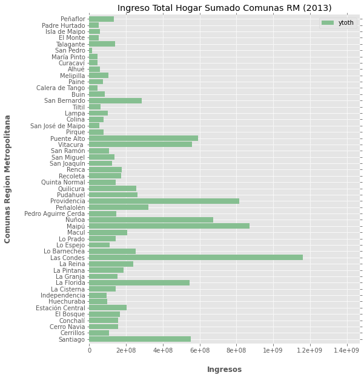

```python
df_ingresos_2013_metropol=df_ingresos_2013[df_ingresos_2013.region==13.0]
df_ingresos_2013_metropol=df_ingresos_2013_metropol[["ytoth","comuna"]].groupby(["comuna"]).sum().reset_index()
df_ingresos_2013_metropol.replace({"comuna": diccionarioComunas},inplace=True)
df_ingresos_2013_metropol.set_index("comuna",inplace=True)
#df_ingresos_2013_metropol.describe()
plot_Bar_Chart(df_ingresos_2013_metropol, [8,10], "Ingresos", "Comunas Region Metropolitana","Ingreso Total Hogar Sumado Comunas RM (2013)")
```

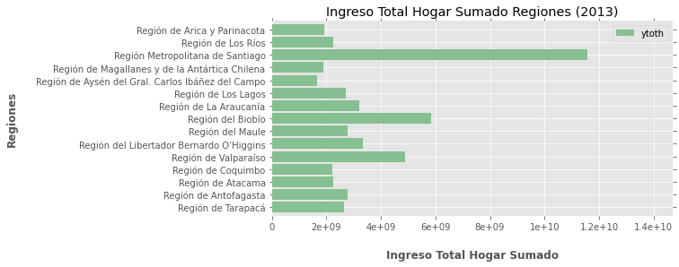

```python
df_ingresos_2013_regiones=df_ingresos_2013[["ytoth","region"]].groupby(["region"]).sum().reset_index()
df_ingresos_2013_regiones.replace({"region": diccionarioRegiones},inplace=True)
df_ingresos_2013_regiones.set_index("region",inplace=True)
#df_ingresos_2013_regiones.describe()
plot_Bar_Chart(df_ingresos_2013_regiones, [8,4], "Ingreso Total Hogar Sumado", "Regiones","Ingreso Total Hogar Sumado Regiones (2013)")
```

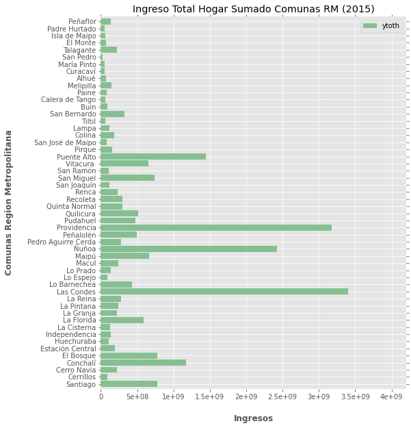

```python
df_ingresos_2015_metropol=df_ingresos_2015[df_ingresos_2015.region==13.0]
df_ingresos_2015_metropol=df_ingresos_2015_metropol[["ytoth","comuna"]].groupby(["comuna"]).sum().reset_index()
df_ingresos_2015_metropol.replace({"comuna": diccionarioComunas},inplace=True)
df_ingresos_2015_metropol.set_index("comuna",inplace=True)
#df_ingresos_2015_metropol.describe()
plot_Bar_Chart(df_ingresos_2015_metropol, [8,10], "Ingresos", "Comunas Region Metropolitana","Ingreso Total Hogar Sumado Comunas RM (2015)")
```

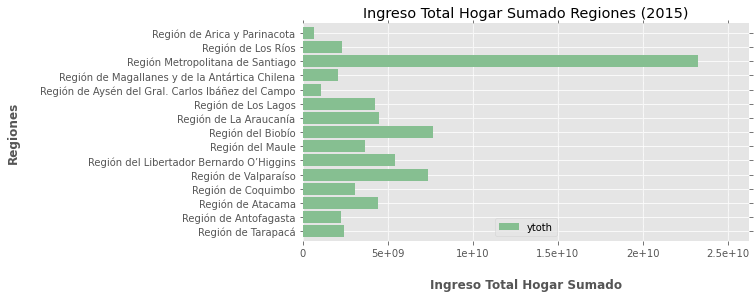

```python
df_ingresos_2015_regiones=df_ingresos_2015[["ytoth","region"]].groupby(["region"]).sum().reset_index()
df_ingresos_2015_regiones.replace({"region": diccionarioRegiones},inplace=True)
df_ingresos_2015_regiones.set_index("region",inplace=True)
#df_ingresos_2015_regiones.describe()
plot_Bar_Chart(df_ingresos_2015_regiones, [8,4], "Ingreso Total Hogar Sumado", "Regiones","Ingreso Total Hogar Sumado Regiones (2015)")
```

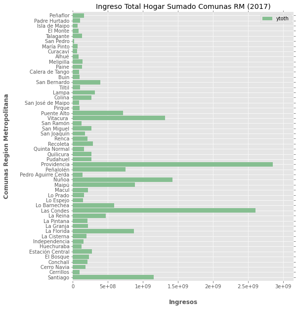

```python
df_ingresos_2017_metropol=df_ingresos_2017[df_ingresos_2017.region==13.0]
df_ingresos_2017_metropol=df_ingresos_2017_metropol[["ytoth","comuna"]].groupby(["comuna"]).sum().reset_index()
df_ingresos_2017_metropol.replace({"comuna": diccionarioComunas},inplace=True)
df_ingresos_2017_metropol.set_index("comuna",inplace=True)
#df_ingresos_2017_metropol.describe()
plot_Bar_Chart(df_ingresos_2017_metropol, [8,10], "Ingresos", "Comunas Region Metropolitana","Ingreso Total Hogar Sumado Comunas RM (2017)")
```

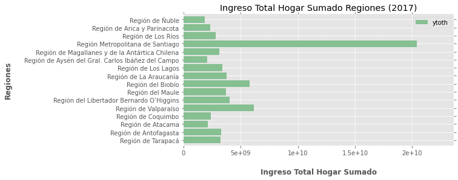

```python
df_ingresos_2017_regiones=df_ingresos_2017[["ytoth","region"]].groupby(["region"]).sum().reset_index()
df_ingresos_2017_regiones.replace({"region": diccionarioRegiones},inplace=True)
df_ingresos_2017_regiones.set_index("region",inplace=True)
#df_ingresos_2017_regiones.describe()
plot_Bar_Chart(df_ingresos_2017_regiones, [8,4], "Ingreso Total Hogar Sumado", "Regiones","Ingreso Total Hogar Sumado Regiones (2017)")
```

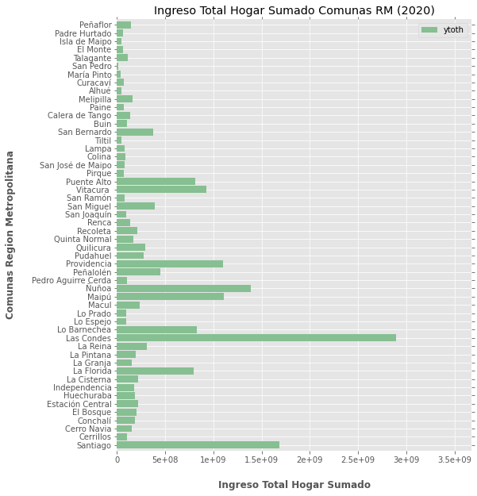

```python
df_ingresos_2020_metropol=df_ingresos_2020[df_ingresos_2020.region==13.0]
df_ingresos_2020_metropol=df_ingresos_2020_metropol[["ytoth","comuna"]].groupby(["comuna"]).sum().reset_index()
df_ingresos_2020_metropol.replace({"comuna": diccionarioComunas},inplace=True)
df_ingresos_2020_metropol.set_index("comuna",inplace=True)
plot_Bar_Chart(df_ingresos_2020_metropol, [8,10], "Ingreso Total Hogar Sumado", "Comunas Region Metropolitana","Ingreso Total Hogar Sumado Comunas RM (2020)")
```

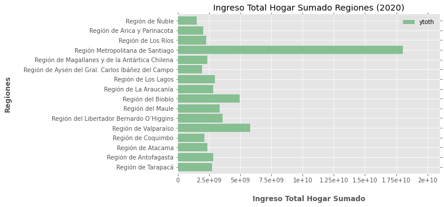

```python
df_ingresos_2020_regiones=df_ingresos_2020[["ytoth","region"]].groupby(["region"]).sum().reset_index()
df_ingresos_2020_regiones.replace({"region": diccionarioRegiones},inplace=True)
df_ingresos_2020_regiones.set_index("region",inplace=True)
#df_ingresos_2020_regiones.describe()
plot_Bar_Chart(df_ingresos_2020_regiones, [8,5], "Ingreso Total Hogar Sumado", "Regiones","Ingreso Total Hogar Sumado Regiones (2020)")
```

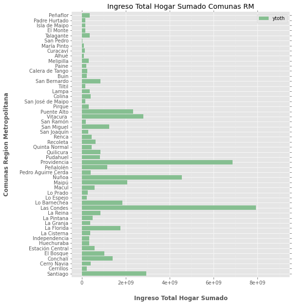

```python
df_folio_metropol=df_folio[df_folio.region==13.0]
df_folio_metropol=df_folio_metropol[["ytoth","comuna"]].groupby(["comuna"]).sum().reset_index()
df_folio_metropol.replace({"comuna": diccionarioComunas},inplace=True)
df_folio_metropol.set_index("comuna",inplace=True)
plot_Bar_Chart(df_folio_metropol, [8,10], "Ingreso Total Hogar Sumado", "Comunas Region Metropolitana","Ingreso Total Hogar Sumado Comunas RM")
```

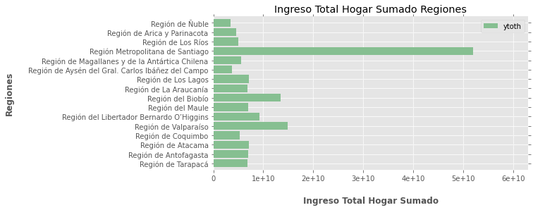

```python
df_folio_regiones=df_folio[["ytoth","region"]].groupby(["region"]).sum().reset_index()
df_folio_regiones.replace({"region": diccionarioRegiones},inplace=True)
df_folio_regiones.set_index("region",inplace=True)
#df_folio_regiones.describe()
plot_Bar_Chart(df_folio_regiones, [8,4], "Ingreso Total Hogar Sumado", "Regiones","Ingreso Total Hogar Sumado Regiones")
```

#### Análisis de ingresos por región en función de los años

```python
data_frames_ingresos = [df_ingresos_2020, df_ingresos_2017, df_ingresos_2015, df_ingresos_2013]
data_frames_ingresos = pd.concat(data_frames_ingresos, ignore_index=True)

data_frames_ingresos_regiones = data_frames_ingresos.groupby(["region","año"], as_index=False).mean()
```

```python
colores = ["#B03A2E", "#884EA0", "#2471A3", "#17A589", "#D4AC0D", "#2E4053", "#BA4A00"]
def Ingreso_Region_Año2(datos:pd.DataFrame, nombre:int, indice:int, leyenda:str):
  new_df = datos[datos.region==nombre]
  x = new_df["año"].tolist()
  y = new_df["ytoth"].tolist()
  largo = new_df.shape[0]
  if not x:
    return


  #y = df.groupby("año")["ytoth"].transform("median")##new_df["ytoth"].tolist()

  plt.scatter(x, y, color=colores[indice])

  z = np.polyfit(x, y, 1)
  p = np.poly1d(z)
  plt.plot(x,p(x),"r--", color=colores[indice], label=leyenda)

def plotScatterByRegion(zona:str, listaRegiones:list):
  plt.figure(figsize=(10,4))
  indice = 0
  for i in listaRegiones:
    Ingreso_Region_Año2(data_frames_ingresos_regiones,i,indice, diccionarioRegiones.get(i))
    indice+=1
  plt.title("Ingreso por Encuesta " + zona)
  plt.xlabel("Año")
  plt.ylabel("Ingreso")
  plt.legend(fontsize=8)
  plt.show()
```

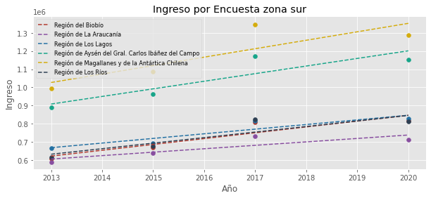

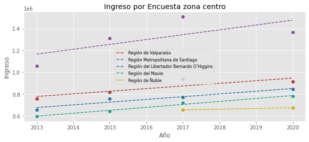

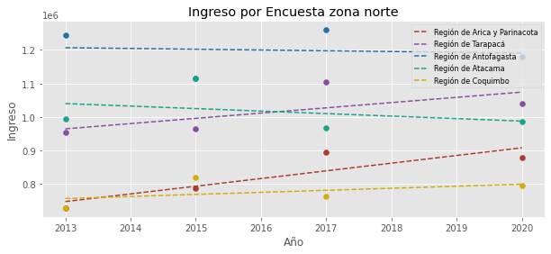

```python
zonaSur = [8,9,10,11,12,14]
zonaCentro = [5,13,6,7,16]
zonaNorte = [15,1,2,3,4]

plotScatterByRegion("zona sur", zonaSur)
plotScatterByRegion("zona centro", zonaCentro)
plotScatterByRegion("zona norte", zonaNorte)
```

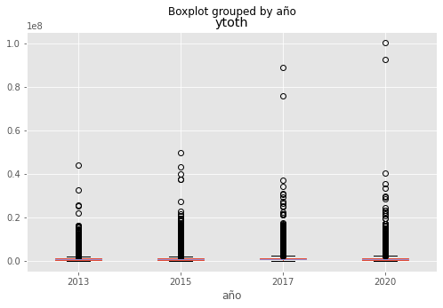

```python
df_folio.boxplot(column=["ytoth"], by='año', figsize=(8,5)) #Con outliers
```

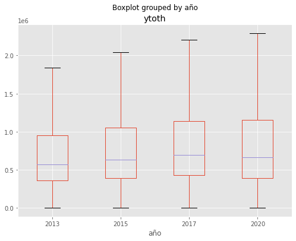

```python
df_folio.boxplot(column=["ytoth"], by='año',showfliers=False, figsize=(8,6)) #Quitando valores fuera de los bigotes
```

# Hito 3: Código

## Pregunta 1

```python
COLUMNAS_EDUCACION = ['folio', 'ytoth', 'e6a', 'e6b', 'numper']

df_ingresos_2013_educacion = filtrar_ingresos(df2013, COLUMNAS_EDUCACION)
df_ingresos_2013_educacion.name = "Casen 2013 Educación"

df_ingresos_2015_educacion = filtrar_ingresos(df2015, COLUMNAS_EDUCACION)
df_ingresos_2015_educacion.name = "Casen 2015 Educación"

df_ingresos_2017_educacion = filtrar_ingresos(df2017, COLUMNAS_EDUCACION)
df_ingresos_2017_educacion.name = "Casen 2017 Educación"

df_ingresos_2020_educacion = filtrar_ingresos(df2020, COLUMNAS_EDUCACION)
df_ingresos_2020_educacion.name = "Casen 2020 Educación"

df_ingresos_2013_educacion["año"] = 2013
df_ingresos_2015_educacion["año"] = 2015
df_ingresos_2017_educacion["año"] = 2017
df_ingresos_2020_educacion["año"] = 2020

data_frames_ingresos_educacion = [df_ingresos_2020_educacion, df_ingresos_2017_educacion, df_ingresos_2015_educacion, df_ingresos_2013_educacion]

df_folio_educacion = pd.concat(data_frames_ingresos_educacion, ignore_index=True)
df_folio_educacion["count"]=1
df_folio_educacion = df_folio_educacion.groupby(["folio"]).sum(numeric_only=True)
df_folio_educacion = df_folio_educacion[df_folio_educacion["count"]== 1]

df_folio_educacion['decil'] = pd.qcut(df_folio_educacion['ytoth'], 10, labels = False)

df_folio_educacion = df_folio_educacion[df_folio_educacion['e6b']!=99]
df_folio_educacion = df_folio_educacion[df_folio_educacion['e6b']!=0]
```

Se decidió revisar con la matriz de correlación:

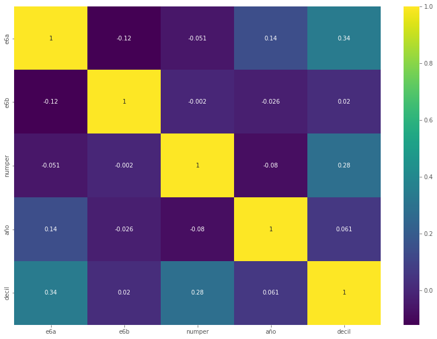

```python
import matplotlib.pyplot as plt
import seaborn as sns

plt.figure(figsize=(14, 10))
sns.heatmap(df_folio_educacion[['e6a', 'e6b', 'numper', 'año', 'decil']].corr(), cmap='viridis', annot=True);
```

Dando cuenta que las variables elegidas poseen correlación positiva con la variable a predecir.

```python
X = []
y = []
for index, row in df_folio_educacion.iterrows():
  X.append([row['e6a'], row['e6b']])
  y.append(row['decil'])
```

```python
from sklearn.neighbors import KNeighborsClassifier
from sklearn.tree import DecisionTreeClassifier

classifiers = {
    "Árbol de Decisiones": DecisionTreeClassifier(),
    "K Nearest Neighbors": KNeighborsClassifier(),
}
```

```python
from sklearn.model_selection import train_test_split
X_train, X_test, y_train, y_test = train_test_split(X, y, test_size=.33, stratify=y)
```

```python
from sklearn.metrics import f1_score, recall_score, precision_score
from sklearn.model_selection import train_test_split
import numpy as np

def run_classifier(clf, X, y, num_tests=100):
    metrics = {'f1-score': [], 'precision': [], 'recall': []}

    for _ in range(num_tests):
        X_train, X_test, y_train, y_test = train_test_split(X, y, test_size=.30)
        clf.fit(X_train, y_train)
        predictions = clf.predict(X_test)
        metrics['y_pred'] = predictions
        metrics['f1-score'].append(f1_score(y_test, predictions, average='micro'))
        metrics['recall'].append(recall_score(y_test, predictions, average='micro'))
        metrics['precision'].append(precision_score(y_test, predictions, average='micro'))
    return metrics
```

```python
results = {}
for name, clf in classifiers.items():
    metrics = run_classifier(clf, X, y, num_tests=10)
    results[name] = metrics
    print("----------------")
    print("Resultados para clasificador: ", name)
    print("Precision promedio:", np.array(metrics['precision']).mean())
    print("Recall promedio:", np.array(metrics['recall']).mean())
    print("F1-score promedio:", np.array(metrics['f1-score']).mean())
    print("----------------\n\n")
```

```
----------------
Resultados para clasificador:  Árbol de Decisiones
Precision promedio: 0.17648544084707798
Recall promedio: 0.17648544084707798
F1-score promedio: 0.176485440847078
----------------


----------------
Resultados para clasificador:  K Nearest Neighbors
Precision promedio: 0.13437181836693138
Recall promedio: 0.13437181836693138
F1-score promedio: 0.13437181836693138
----------------
```

Dado que no se obtuvieron los resultados esperados, se procedió a tomar el problema como uno de clasificación binaria, esto con el fin de mejorar los resultados.

### Código para responder si se puede predecir el nivel económico (bajo o sobre la línea de pobreza extrema) según el nivel educativo

```python
df_folio_educacion['pobreza'] = 0
X = []
y = []
for index, row in df_folio_educacion.iterrows():
  ytoth = row['ytoth']
  numper = row['numper']
  ipc = ytoth/numper
  if ipc < 245592:
    df_folio_educacion.loc[index, 'pobreza'] = 0 # bajo línea de pobreza extrema
    y.append(0)
  else:
    df_folio_educacion.loc[index, 'pobreza'] = 1 # sobre línea de pobreza extrema
    y.append(1)
  X.append([row['e6a'], row['e6b']])
```

Se revisa la matriz de correlación con el nuevo atributo 'pobreza':

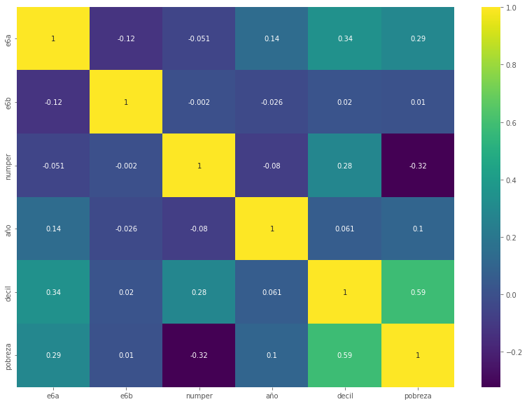

```python
plt.figure(figsize=(14, 10))
sns.heatmap(df_folio_educacion[['e6a', 'e6b', 'numper', 'año', 'decil', 'pobreza']].corr(), cmap='viridis', annot=True);
```

```python
classifiers2 = {
    "Árbol de Decisiones": DecisionTreeClassifier(),
    "K Nearest Neighbors": KNeighborsClassifier(),
}
```

```python
results = {}
for name, clf in classifiers2.items():
    metrics = run_classifier(clf, X, y, num_tests=10)
    results[name] = metrics
    print("----------------")
    print("Resultados para clasificador: ", name)
    print("Precision promedio:", np.array(metrics['precision']).mean())
    print("Recall promedio:", np.array(metrics['recall']).mean())
    print("F1-score promedio:", np.array(metrics['f1-score']).mean())
    print("----------------\n\n")
```

```
----------------
Resultados para clasificador:  Árbol de Decisiones
Precision promedio: 0.6627122785583385
Recall promedio: 0.6627122785583385
F1-score promedio: 0.6627122785583385
----------------


----------------
Resultados para clasificador:  K Nearest Neighbors
Precision promedio: 0.6103767053553246
Recall promedio: 0.6103767053553246
F1-score promedio: 0.6103767053553246
----------------
```

## Pregunta 2

```python
import pandas as pd
import matplotlib.pyplot as plt
import seaborn as sns
from sklearn import preprocessing
import numpy as np
from sklearn.naive_bayes import CategoricalNB
from sklearn.ensemble import RandomForestClassifier
from sklearn.metrics import accuracy_score
from sklearn.metrics import f1_score
from sklearn.metrics import recall_score
from sklearn.metrics import precision_score
from sklearn.model_selection import train_test_split
import pickle
df2013 = pd.read_stata('/content/drive/MyDrive/Matos/BBDD/casen_2013_mn_b_principal.dta', convert_categoricals=False)
df2015 = pd.read_stata('/content/drive/MyDrive/Matos/BBDD/casen_2015.dta',convert_categoricals=False)
df2017 = pd.read_stata('/content/drive/MyDrive/Matos/BBDD/casen_2017.dta', convert_categoricals=False)
```

```python
df2013.name = "Casen 2013"
df2015.name = "Casen 2015"
df2017.name = "Casen 2017"
data_frames = [df2013, df2015, df2017]
```

```python
"""Notamos que hay ciertos atributos que tienen distintos nombres en las distintas tablas.
Por esto, se crean nuevos atributos para estandarizar los datos"""
#1) Tipo de vivienda: Este atributo se llama v1 en las 4 tablas, pero tiene distintos valores
""" En la tabla del 2013, el valor "vivienda tradicional indigena" no existe, y está incluido en
 el valor "rancho, choza o ruca", que en las otras tablas se llama "rancho o choza". Además, en la
 tabla del 2020 las casas y departamentos están englobadas en otro atributo """
#Se imprime los valores posibles de v1 para cada tabla y su cantidad
list(map( lambda tabla: print(tabla.name + ": "+ str(tabla.groupby(['v1']).count()['folio'])), data_frames))
print('Casen 2013, no tiene 10 valores posibles, porque falta el caso de vivienda indigena')
```

```
Casen 2013: v1
1    108762
2     62388
3     29805
4      3703
5     12435
6       274
7       861
8       235
9        28
Name: folio, dtype: int64
Casen 2015: v1
1     140690
2      78545
3      26336
4       5809
5      13006
6        550
7       1597
8         78
9        195
10       162
Name: folio, dtype: int64
Casen 2017: v1
1.0     110486
2.0      57069
3.0      27948
4.0       6200
5.0      12341
6.0        715
7.0       1190
8.0         31
9.0        331
10.0       128
Name: folio, dtype: int64
Casen 2013, no tiene 10 valores posibles, porque falta el caso de vivienda indigena
```

```python
#Se cambian los valores de las tablas
# 1) para no borrar el caso de vivienda indigena se dejan todas las tablas con el formato de la tabla del 2013

for df in data_frames[1:3]:
  df['v1'] = df['v1'].map({1:1, 2:2, 3:3, 4:4, 5:5, 6:6, 7:7, 8:8, 9:8, 10:9}, na_action=None)
```

```python
#Se comprueba que los valores van desde el 1 al 9
list(map( lambda tabla: print(tabla.name + ": "+ str(tabla.v1.unique())), data_frames))
#Se comprueba que la cantidad de los otros valores sigue siendo la misma y que solo cambian los 8 y 9
list(map( lambda tabla: print(tabla.name + ": "+ str(tabla.groupby(['v1']).count()['folio'])), data_frames))
```

```
Casen 2013: [4 1 3 9 2 5 6 7 8]
Casen 2015: [2 3 1 4 5 8 7 6 9]
Casen 2017: [3 4 2 7 1 5 6 8 9]
Casen 2013: v1
1    108762
2     62388
3     29805
4      3703
5     12435
6       274
7       861
8       235
9        28
Name: folio, dtype: int64
Casen 2015: v1
```

[output cut: 21 more lines]

```
[None, None, None]
```

```python
#Ahora, para la variable de la cantidad de dormitorios, creamos otra, ya que, en varias tablas
# tienen nombres distintos
df2013['numDorm'] = df2013.v29a
df2015['numDorm'] = df2015.v29a
df2017['numDorm'] = df2017.v27a
```

```python
#Lo mismo ocurre para la que indica de donde se obtiene el agua
df2013['agua'] = df2013.v23
df2015['agua'] = df2015.v23
df2017['agua'] = df2017.v20
```

```python
#Lo mismo ocurre para la que indica el sistema de excretas
df2013['excrt'] = df2013.v25
df2015['excrt'] = df2015.v25
df2017['excrt'] = df2017.v23
```

```python
#Se ven las columnas que se utilizarán para los modelos
COLUMNAS_PRED_REG = ['folio', 'ytoth', 'numper', 'v1', 'numDorm', 'agua', 'excrt', 'expr', 'comuna', 'region']
```

```python
def filtrar_columnas(data: pd.DataFrame) -> pd.DataFrame:
  """ Filtra las columnas relevantes al analisis de ingresos"""
  new_data_frame = data[COLUMNAS_PRED_REG]
  new_data_frame = new_data_frame.groupby(['folio']).first().reset_index()
  new_data_frame.reset_index(drop=True, inplace=True)

  # Chequeo de que se hizo bien la agrupación
  folio_count = data['folio'].nunique()
  new_data_row_count = len(new_data_frame)
  assert folio_count == new_data_row_count

  return new_data_frame
```

```python
df_reg_2013 = filtrar_columnas(df2013)
df_reg_2013.name = "Casen 2013"
df_reg_2013.describe()
```

|  | folio | ytoth | numper | v1 | numDorm | agua | excrt | expr | comuna | region |
| --- | --- | --- | --- | --- | --- | --- | --- | --- | --- | --- |
| count | 6.672500e+04 | 6.672500e+04 | 66725.000000 | 66725.000000 | 66725.000000 | 66725.000000 | 66725.000000 | 66725.000000 | 66725.000000 | 66725.000000 |
| mean | 8.675659e+10 | 7.795869e+05 | 3.272357 | 1.909179 | 2.776815 | 1.411690 | 1.356523 | 79.038262 | 8675.509135 | 8.472057 |
| std | 3.838544e+10 | 9.112518e+05 | 1.631987 | 1.231820 | 2.215789 | 1.075118 | 0.913596 | 133.686527 | 3838.545866 | 3.862636 |
| min | 1.101100e+10 | 0.000000e+00 | 1.000000 | 1.000000 | 0.000000 | 1.000000 | 1.000000 | 2.000000 | 1101.000000 | 1.000000 |
| 25% | 5.804105e+10 | 3.391300e+05 | 2.000000 | 1.000000 | 2.000000 | 1.000000 | 1.000000 | 28.000000 | 5804.000000 | 5.000000 |
| 50% | 8.313100e+10 | 5.437250e+05 | 3.000000 | 1.000000 | 3.000000 | 1.000000 | 1.000000 | 50.000000 | 8313.000000 | 8.000000 |
| 75% | 1.310310e+11 | 9.000000e+05 | 4.000000 | 2.000000 | 3.000000 | 1.000000 | 1.000000 | 89.000000 | 13103.000000 | 13.000000 |
| max | 1.520130e+11 | 4.390000e+07 | 19.000000 | 9.000000 | 99.000000 | 9.000000 | 9.000000 | 6812.000000 | 15201.000000 | 15.000000 |

```python
df_reg_2015 = filtrar_columnas(df2015)
df_reg_2015.name = "Casen 2015"
df_reg_2015.describe()
```

|  | folio | ytoth | numper | v1 | numDorm | agua | excrt | expr | comuna | region |
| --- | --- | --- | --- | --- | --- | --- | --- | --- | --- | --- |
| count | 8.388700e+04 | 8.388700e+04 | 83887.000000 | 83887.000000 | 83887.000000 | 83887.000000 | 83887.000000 | 83887.000000 | 83887.000000 | 83887.000000 |
| mean | 8.613018e+10 | 8.879201e+05 | 3.179432 | 1.852254 | 2.825861 | 1.432332 | 1.358756 | 65.026929 | 8612.863078 | 8.400086 |
| std | 3.653360e+10 | 1.147247e+06 | 1.600927 | 1.240547 | 1.626931 | 1.075991 | 0.881089 | 78.813550 | 3653.364464 | 3.684795 |
| min | 1.101100e+10 | 0.000000e+00 | 1.000000 | 1.000000 | 0.000000 | 1.000000 | 1.000000 | 1.000000 | 1101.000000 | 1.000000 |
| 25% | 5.804103e+10 | 3.801110e+05 | 2.000000 | 1.000000 | 2.000000 | 1.000000 | 1.000000 | 23.000000 | 5804.000000 | 5.000000 |
| 50% | 8.303101e+10 | 6.081670e+05 | 3.000000 | 1.000000 | 3.000000 | 1.000000 | 1.000000 | 46.000000 | 8303.000000 | 8.000000 |
| 75% | 1.310310e+11 | 1.000000e+06 | 4.000000 | 2.000000 | 3.000000 | 1.000000 | 1.000000 | 83.000000 | 13103.000000 | 13.000000 |
| max | 1.520130e+11 | 1.104056e+08 | 17.000000 | 9.000000 | 99.000000 | 7.000000 | 8.000000 | 4070.000000 | 15201.000000 | 15.000000 |

```python
df_reg_2017 = filtrar_columnas(df2017)
df_reg_2017.name = "Casen 2017"
df_reg_2017.describe()
```

|  | folio | ytoth | numper | v1 | numDorm | agua | excrt | expr | comuna | region |
| --- | --- | --- | --- | --- | --- | --- | --- | --- | --- | --- |
| count | 7.094800e+04 | 7.094800e+04 | 70948.000000 | 70948.000000 | 70948.000000 | 70948.000000 | 70948.000000 | 70948.000000 | 70948.000000 | 70948.000000 |
| mean | 8.752160e+11 | 9.963763e+05 | 3.047739 | 1.949583 | 2.997407 | 1.452148 | 1.346606 | 81.666798 | 9065.678779 | 8.873386 |
| std | 3.865637e+11 | 1.325235e+06 | 1.561204 | 1.302103 | 3.459879 | 1.139776 | 0.945598 | 91.317638 | 4131.152049 | 4.153410 |
| min | 1.101100e+11 | 0.000000e+00 | 1.000000 | 1.000000 | 0.000000 | 1.000000 | 1.000000 | 2.000000 | 1101.000000 | 1.000000 |
| 25% | 6.101105e+11 | 4.310910e+05 | 2.000000 | 1.000000 | 2.000000 | 1.000000 | 1.000000 | 33.000000 | 6101.000000 | 6.000000 |
| 50% | 8.401106e+11 | 6.849435e+05 | 3.000000 | 1.000000 | 3.000000 | 1.000000 | 1.000000 | 62.000000 | 9101.000000 | 9.000000 |
| 75% | 1.310610e+12 | 1.115308e+06 | 4.000000 | 2.000000 | 3.000000 | 1.000000 | 1.000000 | 103.000000 | 13115.000000 | 13.000000 |
| max | 1.520130e+12 | 8.905000e+07 | 19.000000 | 9.000000 | 99.000000 | 9.000000 | 9.000000 | 5828.000000 | 16305.000000 | 16.000000 |

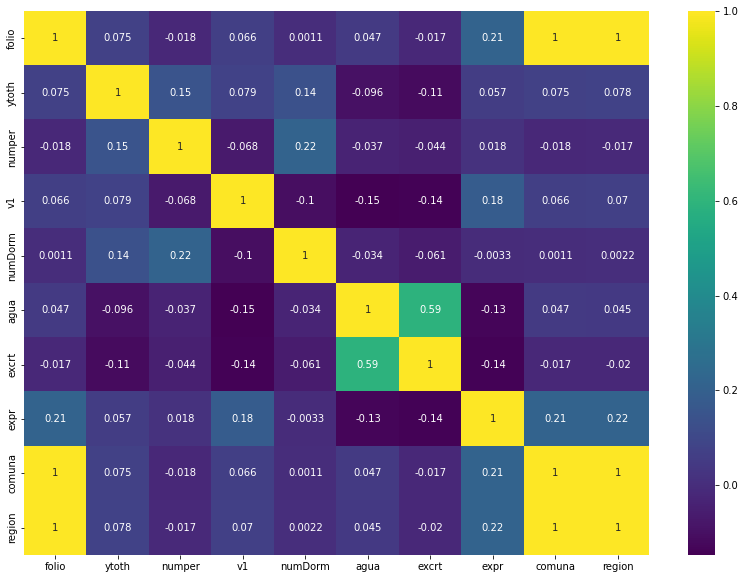

```python
plt.figure(figsize=(14, 10))
sns.heatmap(df_reg_2015.corr(), cmap='viridis', annot=True);
```

```python
def getXy(df, columnasX, columnaY):
  X = df.loc[:,columnasX].to_numpy()
  y = df.loc[:,columnaY].to_numpy()
  return X, y

columnasClasRegion = ['ytoth', 'numper', 'v1', 'numDorm', 'agua', 'excrt', 'expr']
X2013, y2013 = getXy(df_reg_2013, columnasClasRegion, 'region')
```

```python
from sklearn.model_selection import train_test_split

X_train, X_test, y_train, y_test = train_test_split(X2013, y2013, test_size=.33, random_state=23,
                                                    stratify=y2013)
```

```python
from sklearn.metrics import accuracy_score
from sklearn.metrics import f1_score
from sklearn.metrics import recall_score
from sklearn.metrics import precision_score
```

```python
from sklearn.neighbors import KNeighborsClassifier
knn = KNeighborsClassifier(n_neighbors=3)
y_pred3 = knn.fit(X_train, y_train).predict(X_test)
print("Accuracy:", accuracy_score(y_test, y_pred3))
print("Precision:", precision_score(y_test, y_pred3, average='weighted'))
print("Recall:", recall_score(y_test, y_pred3, average='weighted'))
print("F1-Score:", f1_score(y_test, y_pred3, average='weighted'))
```

```
Accuracy: 0.13891916439600363
Precision: 0.1804757397007583
Recall: 0.13891916439600363
F1-Score: 0.144906647770531
```

```python
from sklearn.ensemble import RandomForestClassifier
clf = RandomForestClassifier(max_depth=6, random_state=0)
y_pred2 = clf.fit(X_train, y_train).predict(X_test)
print("Accuracy:", accuracy_score(y_test, y_pred2))
print("Precision:", precision_score(y_test, y_pred2, average='weighted'))
print("Recall:", recall_score(y_test, y_pred2, average='weighted'))
print("F1-Score:", f1_score(y_test, y_pred2, average='weighted'))
```

```
Accuracy: 0.3388283378746594
Precision: 0.35783034339887604
Recall: 0.3388283378746594
F1-Score: 0.28119856519257375
```

Llegado a este punto, no fue posible correr Naive Bayes en Google Colab, por lo que fue necesario correrlo en local. A continuación, se muestra lo hecho tomando en cuenta el oversampling.

```python
# Una vez filtradas las columnas, se trabaja con el factor de expansión regional (expr)
# Usandolo para realizar un Oversampling a cada vivienda según su factor
def oversampling(DF):
    df = DF.reset_index()
    for index, row in df.iterrows():
        numNewRows = int(row['expr'] - 1)//5 #Se divide en 5 para que no se demore mucho en correr
        df = df.append([row]*numNewRows, ignore_index = True)
    return df
```

```python
df_reg_2013 = oversampling(df_reg_2013).reset_index()
df_reg_2013.to_csv('/content/drive/MyDrive/Matos/BBDD/df_reg_2013.csv')
```

```python
df_reg_2015 = oversampling(df_reg_2015).reset_index()
df_reg_2015.to_csv('/content/drive/MyDrive/Matos/BBDD/df_reg_2015.csv')
```

```python
df_reg_2017 = oversampling(df_reg_2017).reset_index()
df_reg_2017.to_csv('/content/drive/MyDrive/Matos/BBDD/df_reg_2017.csv')
```

```python
def getXy(df, columnasX, columnaY, columnaY2):
  X2 = df.loc[:,columnasX + [columnaY]]
  y2 = df.loc[:,columnaY2]
  X2_train, X2_test, y2_train, y2_test = train_test_split(X2, y2, test_size=.33, random_state=23,
                                                    stratify=y2)
  # Los sets para predecir regiones
  X_train = X2_train[columnasX].to_numpy()
  X_test = X2_test[columnasX].to_numpy()
  y_train = X2_train.loc[:,columnaY].to_numpy()
  y_test = X2_test.loc[:,columnaY].to_numpy()

  # Los sets para predecir comunas
  X2_train = X2_train.to_numpy()
  X2_test = X2_test.to_numpy()
  y2_train = y2_train.to_numpy()
  y2_test = y2_test.to_numpy()
  return [X_train, X_test, y_train, y_test], [X2_train, X2_test, y2_train, y2_test]
```

```python
columnasClasRegion = ['ytoth', 'ypcap', 'numper', 'v1', 'v2', 'zona', 'numDorm', 'agua', 'excrt', 'expr', 'expc']
Xy2013Reg, Xy2013Com = getXy(df_reg_2013, columnasClasRegion, 'region', 'comuna')
X_train, X_test, y_train, y_test = Xy2013Reg
```

```python
cnb = CategoricalNB()
y_pred2 = cnb.fit(X_train, y_train).predict(X_test)
print("Accuracy:", accuracy_score(y_test, y_pred2))
print("Precision:", precision_score(y_test, y_pred2, average='weighted'))
print("Recall:", recall_score(y_test, y_pred2, average='weighted'))
print("F1-Score:", f1_score(y_test, y_pred2, average='weighted'))
```

```
Accuracy: 0.8429494450465892
Precision: 0.8456347864730948
Recall: 0.8429494450465892
F1-Score: 0.839701263777311
```

```python
rfc = RandomForestClassifier(max_depth=6, random_state=0)
y_pred2 = rfc.fit(X_train, y_train).predict(X_test)
print("Accuracy:", accuracy_score(y_test, y_pred2))
print("Precision:", precision_score(y_test, y_pred2, average='weighted'))
print("Recall:", recall_score(y_test, y_pred2, average='weighted'))
print("F1-Score:", f1_score(y_test, y_pred2, average='weighted'))
```

```
Accuracy: 0.519345650694427
Precision: 0.49695270159913724
```

```
Recall: 0.519345650694427
F1-Score: 0.451829575245735
```

```python
# Como Naive Bayes funciona mejor, se decide usar ese modelo
# Guardamos el modelo en un archivo
import pickle
pickle.dump(cnb, open('NaiveBayesReg2013.sav', 'wb'))
# Además, se guardan los datos para poder predecir la comuna
pickle.dump(Xy2013Com, open('ComData2013.sav', 'wb'))
```

```python
XyCom = pickle.load(open('./ComData2013.sav', 'rb'))
X_train, X_test, y_train, y_test = XyCom
```

```python
cnb = CategoricalNB()
y_pred2 = cnb.fit(X_train, y_train).predict(X_test)
print("Accuracy:", accuracy_score(y_test, y_pred2))
print("Precision:", precision_score(y_test, y_pred2, average='weighted'))
print("Recall:", recall_score(y_test, y_pred2, average='weighted'))
print("F1-Score:", f1_score(y_test, y_pred2, average='weighted'))
```

[output not shown]

Este error es el que se especifica en la sección de arriba (se intentó solucionar de varias formas, pero seguía sin correr o daba resultados peores que lo esperado)

```python
rfc = RandomForestClassifier(max_depth=3)
y_pred2 = rfc.fit(X_train, y_train).predict(X_test)
print("Accuracy:", accuracy_score(y_test, y_pred2))
print("Precision:", precision_score(y_test, y_pred2, average='weighted'))
print("Recall:", recall_score(y_test, y_pred2, average='weighted'))
print("F1-Score:", f1_score(y_test, y_pred2, average='weighted'))
```

```
Accuracy: 0.14811360651100525
```

```
Precision: 0.07005696462769592
Recall: 0.14811360651100525
F1-Score: 0.0757880957801443
```

## Pregunta 3

```python
import seaborn as sns
from scipy.cluster.hierarchy import dendrogram, linkage
from sklearn.cluster import KMeans
from sklearn import datasets
import matplotlib.pyplot as plt
from sklearn.cluster import AgglomerativeClustering
from sklearn.decomposition import PCA
from sklearn.neighbors import NearestNeighbors
from sklearn.cluster import DBSCAN
from sklearn.metrics import silhouette_score
```

```python
def filtrar_nuevo(data: pd.DataFrame, columns) -> pd.DataFrame:
  """ Filtra las columnas relevantes al analisis de ingresos"""
  new_data_frame = data[columns]
  return new_data_frame
```

```python
AGGREGATE = {
            'folio': 'first', 'numper': 'first', 'region': 'first',
            'ytoth': 'sum', 'o10': 'sum',
            'educ': 'max',
            's12': 'min', 's13': 'mean'
}

COLUMNAS = list(AGGREGATE.keys())
```

```python
# Solo 2017
df_datos = filtrar_nuevo(df2017, COLUMNAS)

# Eliminar "no sabe"
df_datos = df_datos[df_datos['educ']!=99]
df_datos = df_datos[df_datos['s12']!=99]
df_datos = df_datos[df_datos['s13']!=9]

# Agrupar y agregar
df_datos = df_datos.groupby(['folio'])
df_datos = df_datos.agg(AGGREGATE)

# Remover datos nulos
df_datos = df_datos[COLUMNAS[1:]].dropna()

# Normalizar ingresos
df_datos['ytoth'] = df_datos['ytoth'] / df_datos['ytoth'].abs().max()

# Ordenar regiones
regiones = {1: 1, 2: 2, 3: 3, 4: 4, 5: 5, 6: 7, 7: 8, 8: 10, 9: 11, 10: 13,11: 14,12: 15,13: 6,14: 12,15: 0,16: 9}
# 7: RM
df_datos['region'] = df_datos['region'].apply(lambda x: regiones[x])
```

```python
df_datos.describe()
```

|  | numper | region | ytoth | o10 | educ | s12 | s13 |
| --- | --- | --- | --- | --- | --- | --- | --- |
| count | 70026.000000 | 70026.000000 | 70026.000000 | 70026.000000 | 70026.000000 | 70026.000000 | 70026.000000 |
| mean | 3.057136 | 7.460415 | 0.006900 | 54.114872 | 6.240568 | 2.651158 | 5.636952 |
| std | 1.559247 | 3.790627 | 0.011802 | 44.259467 | 3.299747 | 1.956195 | 1.032949 |
| min | 1.000000 | 0.000000 | 0.000000 | 0.000000 | 0.000000 | 1.000000 | 1.000000 |
| 25% | 2.000000 | 5.000000 | 0.001902 | 20.000000 | 4.000000 | 1.000000 | 5.000000 |
| 50% | 3.000000 | 7.000000 | 0.003999 | 45.000000 | 6.000000 | 2.000000 | 5.833333 |
| 75% | 4.000000 | 10.000000 | 0.008046 | 88.000000 | 9.000000 | 3.000000 | 6.333333 |
| max | 19.000000 | 15.000000 | 1.000000 | 442.000000 | 12.000000 | 9.000000 | 7.000000 |

### Matriz

Se crea la matriz de correlaciones para ver la relacion entre las variables

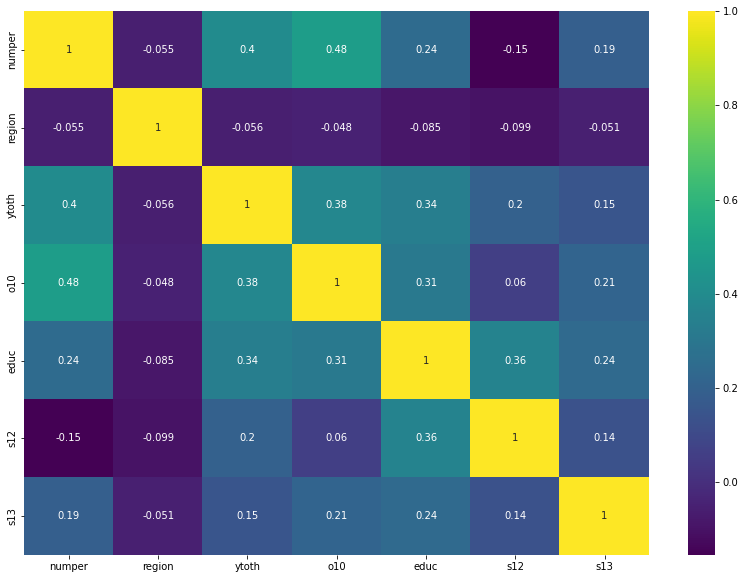

```python
plt.figure(figsize=(14, 10))
sns.heatmap(df_datos.corr(), cmap='viridis', annot=True)
```